```python
import pandas as pd
import numpy as np
import matplotlib.pyplot as plt
import datetime
import seaborn as sns
from pandas_profiling import ProfileReport
from scipy.stats import pearsonr
import scipy.stats as stats
```

```python
from IPython.core.display import display, HTML
display(HTML("<style>.container { width:300% !important; }</style>"))
```

# Préparation des données

```python
customers=pd.read_csv(r"C:\Users\piard\OneDrive\Documents\Projet 6\DAN-P6-donnees\DAN-P6-donnees\customers.csv")
```

```python
customers
```

|  | client_id | sex | birth |
| --- | --- | --- | --- |
| 0 | c_4410 | f | 1967 |
| 1 | c_7839 | f | 1975 |
| 2 | c_1699 | f | 1984 |
| 3 | c_5961 | f | 1962 |
| 4 | c_5320 | m | 1943 |
| ... | ... | ... | ... |
| 8618 | c_7920 | m | 1956 |
| 8619 | c_7403 | f | 1970 |
| 8620 | c_5119 | m | 1974 |
| 8621 | c_5643 | f | 1968 |
| 8622 | c_84 | f | 1982 |

```python
customers.client_id.unique().shape[0]
```

```
8623
```

client_id : clé primaire

```python
(customers.isna().sum()/customers.shape[0]).sort_values(ascending=True)
```

```
NumExpr defaulting to 8 threads.
```

```
client_id    0.0
sex          0.0
birth        0.0
dtype: float64
```

Il n'y a pas de valeurs manquantes dans customers.

```python
products=pd.read_csv(r"C:\Users\piard\OneDrive\Documents\Projet 6\DAN-P6-donnees\DAN-P6-donnees\products.csv")
```

```python
products
```

|  | id_prod | price | categ |
| --- | --- | --- | --- |
| 0 | 0_1421 | 19.99 | 0 |
| 1 | 0_1368 | 5.13 | 0 |
| 2 | 0_731 | 17.99 | 0 |
| 3 | 1_587 | 4.99 | 1 |
| 4 | 0_1507 | 3.99 | 0 |
| ... | ... | ... | ... |
| 3282 | 2_23 | 115.99 | 2 |
| 3283 | 0_146 | 17.14 | 0 |
| 3284 | 0_802 | 11.22 | 0 |
| 3285 | 1_140 | 38.56 | 1 |
| 3286 | 0_1920 | 25.16 | 0 |

```python
products.id_prod.unique().shape[0]
```

```
3287
```

id_prod : clé primaire

```python
(products.isna().sum()/products.shape[0]).sort_values(ascending=True)
```

```
id_prod    0.0
price      0.0
categ      0.0
dtype: float64
```

Il n'y a pas de valeurs manquantes dans products.

```python
products['price'].sort_values()
```

```
731      -1.00
2355      0.62
2272      0.62
370       0.66
1211      0.77
         ...
2779    233.54
1436    236.99
394     247.22
724     254.44
947     300.00
Name: price, Length: 3287, dtype: float64
```

On remarque qu'il y a une valeur négative dans la colonne price de products.

```python
transactions=pd.read_csv(r"C:\Users\piard\OneDrive\Documents\Projet 6\DAN-P6-donnees\DAN-P6-donnees\transactions.csv",sep=';')
```

```python
transactions
```

|  | id_prod | date | session_id | client_id |
| --- | --- | --- | --- | --- |
| 0 | 0_1518 | 2022-05-20 13:21:29.043970 | s_211425 | c_103 |
| 1 | 1_251 | 2022-02-02 07:55:19.149409 | s_158752 | c_8534 |
| 2 | 0_1277 | 2022-06-18 15:44:33.155329 | s_225667 | c_6714 |
| 3 | 2_209 | 2021-06-24 04:19:29.835891 | s_52962 | c_6941 |
| 4 | 0_1509 | 2023-01-11 08:22:08.194479 | s_325227 | c_4232 |
| ... | ... | ... | ... | ... |
| 679527 | 0_1551 | 2022-01-15 13:05:06.246925 | s_150195 | c_8489 |
| 679528 | 1_639 | 2022-03-19 16:03:23.429229 | s_181434 | c_4370 |
| 679529 | 0_1425 | 2022-12-20 04:33:37.584749 | s_314704 | c_304 |
| 679530 | 0_1994 | 2021-07-16 20:36:35.350579 | s_63204 | c_2227 |
| 679531 | 1_523 | 2022-09-28 01:12:01.973763 | s_274568 | c_3873 |

```python
(transactions.isna().sum()/transactions.shape[0]).sort_values(ascending=True)
```

```
id_prod       0.0
date          0.0
session_id    0.0
client_id     0.0
dtype: float64
```

Il n'y a pas de valeurs manquantes dans transactions.

Je fais une jointure full outer join pour ne pas perdre d'informations avec transactions et products.

```python
trpr=transactions.merge(products,how='outer',indicator=True)
```

```python
trpr
```

|  | id_prod | date | session_id | client_id | price | categ | _merge |
| --- | --- | --- | --- | --- | --- | --- | --- |
| 0 | 0_1518 | 2022-05-20 13:21:29.043970 | s_211425 | c_103 | 4.18 | 0.0 | both |
| 1 | 0_1518 | 2021-09-26 12:37:29.780414 | s_95811 | c_6197 | 4.18 | 0.0 | both |
| 2 | 0_1518 | 2021-05-06 17:14:43.117440 | s_30782 | c_682 | 4.18 | 0.0 | both |
| 3 | 0_1518 | 2022-03-16 18:57:10.420103 | s_180057 | c_5932 | 4.18 | 0.0 | both |
| 4 | 0_1518 | 2022-11-12 18:58:10.574853 | s_296584 | c_7217 | 4.18 | 0.0 | both |
| ... | ... | ... | ... | ... | ... | ... | ... |
| 679548 | 0_1624 | NaN | NaN | NaN | 24.50 | 0.0 | right_only |
| 679549 | 2_86 | NaN | NaN | NaN | 132.36 | 2.0 | right_only |
| 679550 | 0_299 | NaN | NaN | NaN | 22.99 | 0.0 | right_only |
| 679551 | 0_510 | NaN | NaN | NaN | 23.66 | 0.0 | right_only |
| 679552 | 0_2308 | NaN | NaN | NaN | 20.28 | 0.0 | right_only |

Je recherche les valeurs qui ne correspondent pas.

```python
trpr[trpr['_merge']=='left_only']
```

|  | id_prod | date | session_id | client_id | price | categ | _merge |
| --- | --- | --- | --- | --- | --- | --- | --- |
| 542560 | 0_2245 | 2022-09-23 07:22:38.636773 | s_272266 | c_4746 | NaN | NaN | left_only |
| 542561 | 0_2245 | 2022-07-23 09:24:14.133889 | s_242482 | c_6713 | NaN | NaN | left_only |
| 542562 | 0_2245 | 2022-12-03 03:26:35.696673 | s_306338 | c_5108 | NaN | NaN | left_only |
| 542563 | 0_2245 | 2021-08-16 11:33:25.481411 | s_76493 | c_1391 | NaN | NaN | left_only |
| 542564 | 0_2245 | 2022-07-16 05:53:01.627491 | s_239078 | c_7954 | NaN | NaN | left_only |
| ... | ... | ... | ... | ... | ... | ... | ... |
| 542776 | 0_2245 | 2021-08-25 09:06:03.504061 | s_80395 | c_131 | NaN | NaN | left_only |
| 542777 | 0_2245 | 2022-03-06 19:59:19.462288 | s_175311 | c_4167 | NaN | NaN | left_only |
| 542778 | 0_2245 | 2022-05-16 11:35:20.319501 | s_209381 | c_4453 | NaN | NaN | left_only |
| 542779 | 0_2245 | 2022-02-11 09:05:43.952857 | s_163405 | c_1098 | NaN | NaN | left_only |
| 542780 | 0_2245 | 2021-12-14 22:34:54.589921 | s_134446 | c_4854 | NaN | NaN | left_only |

On remarque que 0_2245 n'est pas dans le fichier products , je fais donc une imputation dans le fichier products.

```python
products.loc[3287]=['0_2245',products['price'].mean(),0]
```

```python
products
```

|  | id_prod | price | categ |
| --- | --- | --- | --- |
| 0 | 0_1421 | 19.990000 | 0 |
| 1 | 0_1368 | 5.130000 | 0 |
| 2 | 0_731 | 17.990000 | 0 |
| 3 | 1_587 | 4.990000 | 1 |
| 4 | 0_1507 | 3.990000 | 0 |
| ... | ... | ... | ... |
| 3283 | 0_146 | 17.140000 | 0 |
| 3284 | 0_802 | 11.220000 | 0 |
| 3285 | 1_140 | 38.560000 | 1 |
| 3286 | 0_1920 | 25.160000 | 0 |
| 3287 | 0_2245 | 21.856641 | 0 |

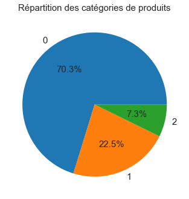

```python
plt.pie(products['categ'].value_counts(),autopct=lambda x:f'{x:.1f}%',labels=products.categ.unique(),textprops={'fontsize': 15})
plt.title("Répartition des catégories de produits",fontsize=15)
plt.show()
```

Je recherche les prix négatifs dans le fichier trpr.

```python
trpr[trpr['price']<0]
```

|  | id_prod | date | session_id | client_id | price | categ | _merge |
| --- | --- | --- | --- | --- | --- | --- | --- |
| 557787 | T_0 | test_2021-03-01 02:30:02.237419 | s_0 | ct_0 | -1.0 | 0.0 | both |
| 557788 | T_0 | test_2021-03-01 02:30:02.237425 | s_0 | ct_0 | -1.0 | 0.0 | both |
| 557789 | T_0 | test_2021-03-01 02:30:02.237437 | s_0 | ct_1 | -1.0 | 0.0 | both |
| 557790 | T_0 | test_2021-03-01 02:30:02.237436 | s_0 | ct_0 | -1.0 | 0.0 | both |
| 557791 | T_0 | test_2021-03-01 02:30:02.237430 | s_0 | ct_0 | -1.0 | 0.0 | both |
| ... | ... | ... | ... | ... | ... | ... | ... |
| 557982 | T_0 | test_2021-03-01 02:30:02.237417 | s_0 | ct_0 | -1.0 | 0.0 | both |
| 557983 | T_0 | test_2021-03-01 02:30:02.237427 | s_0 | ct_1 | -1.0 | 0.0 | both |
| 557984 | T_0 | test_2021-03-01 02:30:02.237449 | s_0 | ct_1 | -1.0 | 0.0 | both |
| 557985 | T_0 | test_2021-03-01 02:30:02.237424 | s_0 | ct_1 | -1.0 | 0.0 | both |
| 557986 | T_0 | test_2021-03-01 02:30:02.237425 | s_0 | ct_1 | -1.0 | 0.0 | both |

```python
trpr[trpr['price']<0]['id_prod'].nunique()
```

```
1
```

Je remarque qu'il y a un produit qui a un prix négatif ,je supprime les lignes contenant ce produit.

```python
transactions=transactions[transactions['id_prod']!='T_0'].copy()
```

```python
transactions['date']=pd.to_datetime(transactions['date'])
```

```python
transactions
```

|  | id_prod | date | session_id | client_id |
| --- | --- | --- | --- | --- |
| 0 | 0_1518 | 2022-05-20 13:21:29.043970 | s_211425 | c_103 |
| 1 | 1_251 | 2022-02-02 07:55:19.149409 | s_158752 | c_8534 |
| 2 | 0_1277 | 2022-06-18 15:44:33.155329 | s_225667 | c_6714 |
| 3 | 2_209 | 2021-06-24 04:19:29.835891 | s_52962 | c_6941 |
| 4 | 0_1509 | 2023-01-11 08:22:08.194479 | s_325227 | c_4232 |
| ... | ... | ... | ... | ... |
| 679527 | 0_1551 | 2022-01-15 13:05:06.246925 | s_150195 | c_8489 |
| 679528 | 1_639 | 2022-03-19 16:03:23.429229 | s_181434 | c_4370 |
| 679529 | 0_1425 | 2022-12-20 04:33:37.584749 | s_314704 | c_304 |
| 679530 | 0_1994 | 2021-07-16 20:36:35.350579 | s_63204 | c_2227 |
| 679531 | 1_523 | 2022-09-28 01:12:01.973763 | s_274568 | c_3873 |

```python
transactions['date']= transactions['date'].dt.strftime('%Y-%m-%d')
```

Je fais une jointure full outer join avec les nouveaux dataframes transactions et products.

```python
trp1=transactions.merge(products,how='outer',indicator=True)
```

```python
trp1[trp1['id_prod']=='T_0']
```

|  | id_prod | date | session_id | client_id | price | categ | _merge |
| --- | --- | --- | --- | --- | --- | --- | --- |
| 679334 | T_0 | NaN | NaN | NaN | -1.0 | 0 | right_only |

Je garde toutes les lignes sauf la ligne avec l'id_prod T_0

```python
trp1=trp1[trp1['id_prod']!='T_0']
```

```python
trp1
```

|  | id_prod | date | session_id | client_id | price | categ | _merge |
| --- | --- | --- | --- | --- | --- | --- | --- |
| 0 | 0_1518 | 2022-05-20 | s_211425 | c_103 | 4.18 | 0 | both |
| 1 | 0_1518 | 2021-09-26 | s_95811 | c_6197 | 4.18 | 0 | both |
| 2 | 0_1518 | 2021-05-06 | s_30782 | c_682 | 4.18 | 0 | both |
| 3 | 0_1518 | 2022-03-16 | s_180057 | c_5932 | 4.18 | 0 | both |
| 4 | 0_1518 | 2022-11-12 | s_296584 | c_7217 | 4.18 | 0 | both |
| ... | ... | ... | ... | ... | ... | ... | ... |
| 679349 | 0_1624 | NaN | NaN | NaN | 24.50 | 0 | right_only |
| 679350 | 2_86 | NaN | NaN | NaN | 132.36 | 2 | right_only |
| 679351 | 0_299 | NaN | NaN | NaN | 22.99 | 0 | right_only |
| 679352 | 0_510 | NaN | NaN | NaN | 23.66 | 0 | right_only |
| 679353 | 0_2308 | NaN | NaN | NaN | 20.28 | 0 | right_only |

Je garde les produits qui correspondent.

```python
trp2=trp1[trp1['_merge']=='both']
```

```python
trp2
```

|  | id_prod | date | session_id | client_id | price | categ | _merge |
| --- | --- | --- | --- | --- | --- | --- | --- |
| 0 | 0_1518 | 2022-05-20 | s_211425 | c_103 | 4.18 | 0 | both |
| 1 | 0_1518 | 2021-09-26 | s_95811 | c_6197 | 4.18 | 0 | both |
| 2 | 0_1518 | 2021-05-06 | s_30782 | c_682 | 4.18 | 0 | both |
| 3 | 0_1518 | 2022-03-16 | s_180057 | c_5932 | 4.18 | 0 | both |
| 4 | 0_1518 | 2022-11-12 | s_296584 | c_7217 | 4.18 | 0 | both |
| ... | ... | ... | ... | ... | ... | ... | ... |
| 679327 | 0_1279 | 2021-06-23 | s_52563 | c_1025 | 20.99 | 0 | both |
| 679328 | 0_1683 | 2021-12-24 | s_139091 | c_5508 | 2.99 | 0 | both |
| 679329 | 0_1379 | 2021-10-16 | s_105547 | c_5425 | 2.99 | 0 | both |
| 679330 | 0_886 | 2021-03-17 | s_7410 | c_7219 | 21.82 | 0 | both |
| 679331 | 0_833 | 2021-09-27 | s_96558 | c_8260 | 2.99 | 0 | both |

```python
produits_invendus=trp1[trp1['_merge']!='both']
```

```python
produits_invendus.shape[0]/products.id_prod.shape[0]*100
```

```
0.6386861313868614
```

0.64 % des produits sont invendus.

Je fais une jointure full outer join de trp2 avec customers.

```python
trp3=trp2.merge(customers,left_on='client_id',right_on='client_id',how='outer',indicator='_merge2')
```

```python
trp3
```

|  | id_prod | date | session_id | client_id | price | categ | _merge | sex | birth | _merge2 |
| --- | --- | --- | --- | --- | --- | --- | --- | --- | --- | --- |
| 0 | 0_1518 | 2022-05-20 | s_211425 | c_103 | 4.18 | 0.0 | both | f | 1986 | both |
| 1 | 0_1518 | 2021-07-20 | s_64849 | c_103 | 4.18 | 0.0 | both | f | 1986 | both |
| 2 | 0_1518 | 2022-08-20 | s_255965 | c_103 | 4.18 | 0.0 | both | f | 1986 | both |
| 3 | 0_1418 | 2022-06-18 | s_225411 | c_103 | 8.57 | 0.0 | both | f | 1986 | both |
| 4 | 0_1418 | 2021-08-18 | s_77214 | c_103 | 8.57 | 0.0 | both | f | 1986 | both |
| ... | ... | ... | ... | ... | ... | ... | ... | ... | ... | ... |
| 679350 | NaN | NaN | NaN | c_7584 | NaN | NaN | NaN | f | 1960 | right_only |
| 679351 | NaN | NaN | NaN | c_90 | NaN | NaN | NaN | m | 2001 | right_only |
| 679352 | NaN | NaN | NaN | c_587 | NaN | NaN | NaN | m | 1993 | right_only |
| 679353 | NaN | NaN | NaN | ct_1 | NaN | NaN | NaN | m | 2001 | right_only |
| 679354 | NaN | NaN | NaN | c_3526 | NaN | NaN | NaN | m | 1956 | right_only |

Je garde que les clients qui ont achetés des produits.

```python
trp4=trp3[trp3['_merge2']=='both'].copy()
```

```python
clients_sans_achats=trp3[trp3['_merge2']!='both']
```

```python
clients_sans_achats.shape[0]/(customers.client_id.shape[0])*100
```

```
0.26672851675750897
```

0.27% des clients n'ont pas achetés.

```python
trp4['date']= pd.to_datetime(trp4['date'])
```

```python
age=2021-trp4['birth']
```

```python
trp5=pd.concat([trp4,age],axis=1)
```

```python
trp5.columns=['id_prod','date','session_id','client_id','price','categ','_merge','sex','birth','_merge2','Age']
```

```python
trp6=trp5.drop(columns=['_merge','_merge2'])
```

```python
trp6=trp6.set_index('date')
```

```python
trp6['Year']=trp6.index.year
```

```python
trp6['Month']=trp6.index.month
```

```python
trp6['Day']=trp6.index.day
```

```python
trp6.loc[(trp6['Age']>=17)&(trp6['Age']<=36),"groupe d'age"]="17-36"
trp6.loc[(trp6['Age']>=37)&(trp6['Age']<=56),"groupe d'age"]="37-56"
trp6.loc[(trp6['Age']>=57)&(trp6['Age']<=76),"groupe d'age"]="57-76"
trp6.loc[(trp6['Age']>=77)&(trp6['Age']<=96),"groupe d'age"]="77-96"
```

```python
trp6
```

| date | id_prod | session_id | client_id | price | categ | sex | birth | Age | Year | Month | Day | groupe d'age |
| --- | --- | --- | --- | --- | --- | --- | --- | --- | --- | --- | --- | --- |
| 2022-05-20 | 0_1518 | s_211425 | c_103 | 4.18 | 0.0 | f | 1986 | 35 | 2022 | 5 | 20 | 17-36 |
| 2021-07-20 | 0_1518 | s_64849 | c_103 | 4.18 | 0.0 | f | 1986 | 35 | 2021 | 7 | 20 | 17-36 |
| 2022-08-20 | 0_1518 | s_255965 | c_103 | 4.18 | 0.0 | f | 1986 | 35 | 2022 | 8 | 20 | 17-36 |
| 2022-06-18 | 0_1418 | s_225411 | c_103 | 8.57 | 0.0 | f | 1986 | 35 | 2022 | 6 | 18 | 17-36 |
| 2021-08-18 | 0_1418 | s_77214 | c_103 | 8.57 | 0.0 | f | 1986 | 35 | 2021 | 8 | 18 | 17-36 |
| ... | ... | ... | ... | ... | ... | ... | ... | ... | ... | ... | ... | ... |
| 2021-07-23 | 2_147 | s_65994 | c_4391 | 181.99 | 2.0 | f | 2001 | 20 | 2021 | 7 | 23 | 17-36 |
| 2022-03-25 | 0_142 | s_184472 | c_1232 | 19.85 | 0.0 | f | 1960 | 61 | 2022 | 3 | 25 | 57-76 |
| 2021-09-25 | 0_142 | s_95415 | c_1232 | 19.85 | 0.0 | f | 1960 | 61 | 2021 | 9 | 25 | 57-76 |
| 2021-03-11 | 2_205 | s_4605 | c_7534 | 100.99 | 2.0 | m | 1992 | 29 | 2021 | 3 | 11 | 17-36 |
| 2022-07-11 | 2_205 | s_236636 | c_7534 | 100.99 | 2.0 | m | 1992 | 29 | 2022 | 7 | 11 | 17-36 |

# Evolution du CA par année et par mois

```python
trpym=trp6[['Year','Month','price']]
```

```python
trpmy1=pd.pivot_table(trpym, index='Month', columns=['Year'], aggfunc=['sum', 'count']).reset_index()
```

```python
trpmy1.columns=['Month','2021ca','2022ca','2023ca','2021ve','2022ve','2023ve']
```

```python
trpmy1
```

|  | Month | 2021ca | 2022ca | 2023ca | 2021ve | 2022ve | 2023ve |
| --- | --- | --- | --- | --- | --- | --- | --- |
| 0 | 1 | NaN | 525448.273206 | 517693.546489 | NaN | 29348.0 | 28945.0 |
| 1 | 2 | NaN | 535811.923054 | 456832.756489 | NaN | 29605.0 | 25552.0 |
| 2 | 3 | 482637.319772 | 515696.953054 | NaN | 28610.0 | 29707.0 | NaN |
| 3 | 4 | 476415.292978 | 493304.932978 | NaN | 28457.0 | 27616.0 | NaN |
| 4 | 5 | 493118.323130 | 517482.306261 | NaN | 28293.0 | 29991.0 | NaN |
| ... | ... | ... | ... | ... | ... | ... | ... |
| 7 | 8 | 482481.499772 | 506642.123130 | NaN | 25659.0 | 28552.0 | NaN |
| 8 | 9 | 507502.959696 | 494311.239772 | NaN | 33326.0 | 28315.0 | NaN |
| 9 | 10 | 320951.736489 | 508136.336413 | NaN | 21606.0 | 28974.0 | NaN |
| 10 | 11 | 516386.296413 | 496905.363054 | NaN | 28321.0 | 28574.0 | NaN |
| 11 | 12 | 526070.276489 | 510350.639848 | NaN | 32464.0 | 28625.0 | NaN |

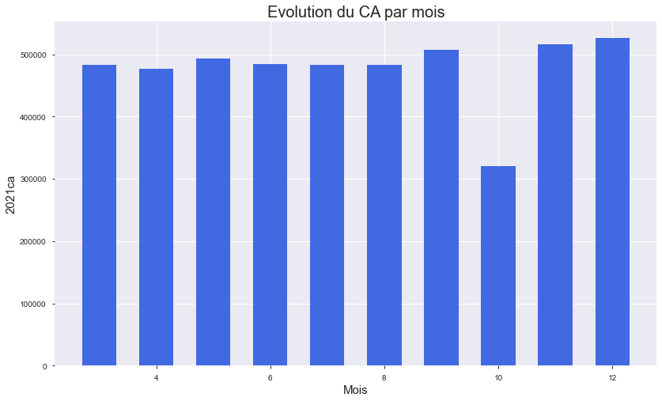

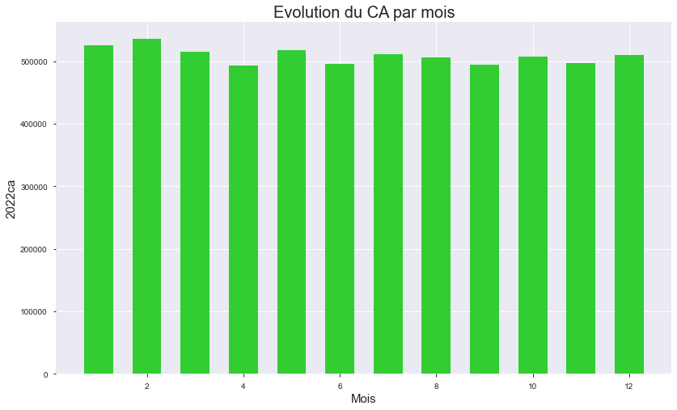

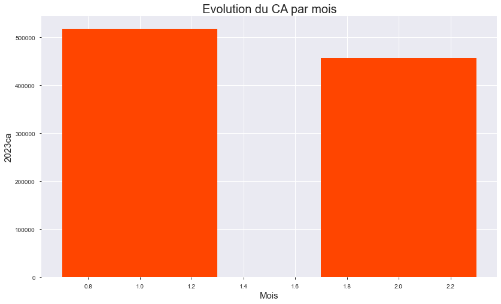

```python
color=['royalblue', 'limegreen', 'orangered']
for i, annee in enumerate(['2021ca','2022ca','2023ca']):
    plt.figure(figsize=(30,8))
    plt.subplot(1,2,2)
    plt.bar(trpmy1['Month'], trpmy1[annee], width=0.6, color=color[i])
    plt.xlabel("Mois",fontsize=15)
    plt.ylabel(f'{annee}',fontsize=15)
    plt.title("Evolution du CA par mois",fontsize=20)
    plt.show()
```

# Evolution du nombre de ventes par année et par mois

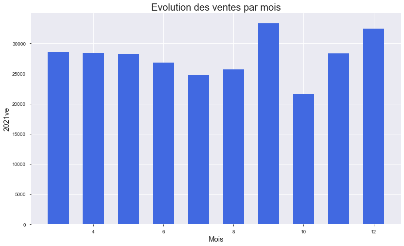

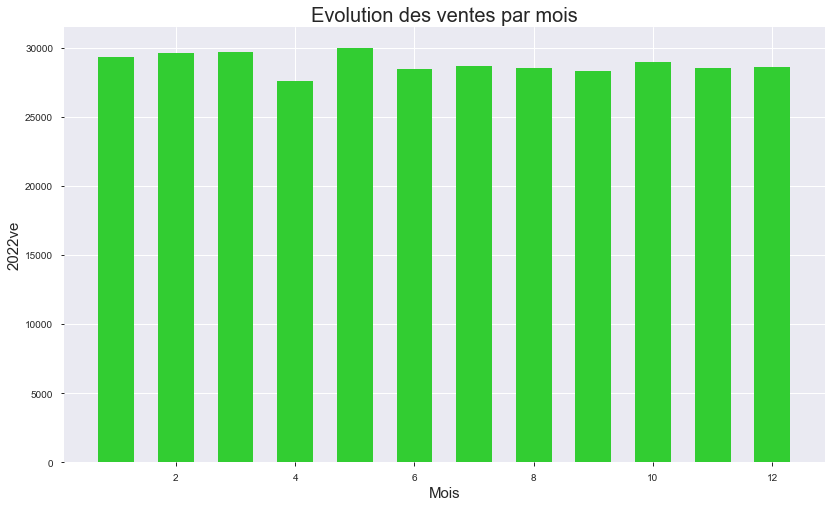

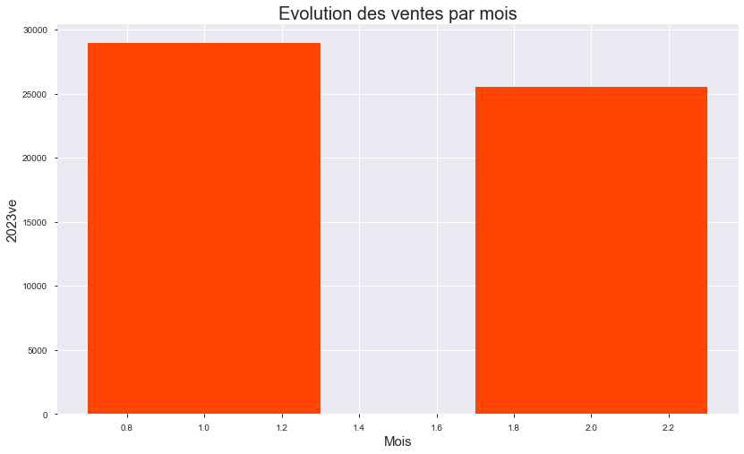

```python
color=['royalblue', 'limegreen', 'orangered']
for i, annee in enumerate(['2021ve','2022ve','2023ve']):
    plt.figure(figsize=(30,8))
    plt.subplot(1,2,2)
    plt.bar(trpmy1['Month'], trpmy1[annee], width=0.6, color=color[i])
    plt.xlabel("Mois",fontsize=15)
    plt.ylabel(f'{annee}',fontsize=15)
    plt.title("Evolution des ventes par mois",fontsize=20)
    plt.show()
```

# CA par an

```python
trp8=trp6.reset_index().groupby(['Year']).sum()
```

```python
trp8=trp8.rename(columns={'price':'ca total'}).reset_index()
```

```python
trp8[['Year','ca total']]
```

|  | Year | ca total |
| --- | --- | --- |
| 0 | 2021 | 4.772728e+06 |
| 1 | 2022 | 6.111305e+06 |
| 2 | 2023 | 9.745263e+05 |

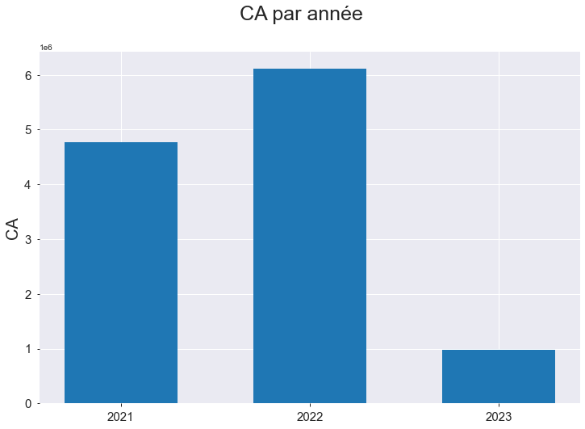

```python
sequence=[2021,2022,2023]
fig,ax=plt.subplots(figsize=(12,8))
ax.bar(sequence,trp8['ca total'],width=0.6)
plt.suptitle('CA par année',fontsize=25)
plt.ylabel('CA',fontsize=20)
plt.xticks(fontsize=15)
plt.yticks(fontsize=15)
plt.xticks(np.arange(2021,2024,1))
plt.show()
```

# Test du Khi-deux pour la catégorie et le sexe

```python
trpcount=pd.crosstab(trp6['categ'], trp6['sex'])
```

```python
trpcount
```

| sex categ | f | m |
| --- | --- | --- |
| 0.0 | 206220 | 209460 |
| 1.0 | 114899 | 112270 |
| 2.0 | 17283 | 19200 |

Hypothèses de départ :

- H0 : Variables indépendantes si p-value > 5%
- H1 : Variables non indépendantes si p-value < 5%

```python
from scipy.stats import chi2_contingency
Khi2_obs, p_value, ddl, effectif_theorique = chi2_contingency(trpcount)
print(f'Le Khi2_obs vaut {Khi2_obs :.2f} , la p-valeur vaut { p_value :.1f} et le nombre de degrés de liberté vaut {ddl :.0f}. ')
```

```
Le Khi2_obs vaut 147.00 , la p-valeur vaut 0.0 et le nombre de degrés de liberté vaut 2.
```

```python
sexcateg=np.array([[206220,209460],[114899,112270],[17283,19200]])
```

```python
sexcateg
```

```
array([[206220, 209460],
       [114899, 112270],
       [ 17283,  19200]])
```

```python
N=sexcateg.sum()
ni = sexcateg.sum(axis=1)
nj = sexcateg.sum(axis=0)
ni, nj, N
```

```
(array([415680, 227169,  36483]), array([338402, 340930]), 679332)
```

```python
nij = ni.reshape(sexcateg.shape[0], 1) *(nj / N)
nij
```

```
array([[207066.56444861, 208613.43555139],
       [113161.81769444, 114007.18230556],
       [ 18173.61785695,  18309.38214305]])
```

```python
d = (sexcateg - nij) ** 2 / nij
d.sum()
```

```
147.00253568681063
```

```python
trpcount.style.background_gradient(cmap='Blues')
```

| sex categ | f | m |
| --- | --- | --- |
| 0.0 | 206220 | 209460 |
| 1.0 | 114899 | 112270 |
| 2.0 | 17283 | 19200 |

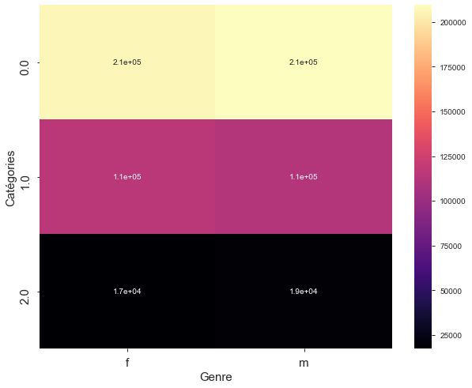

```python
plt.figure(figsize=(10,8))
sns.heatmap(trpcount, annot=True, cmap="magma")
plt.xticks(fontsize=15)
plt.yticks(fontsize=15)
plt.xlabel("Genre",fontsize=15)
plt.ylabel("Catégories",fontsize=15)
plt.show()
```

# Test du Khi-deux pour les groupes d'age et la catégorie

```python
trpcount1=pd.crosstab(trp6["groupe d'age"], trp6["categ"])
```

```python
trpcount1
```

| categ groupe d'age | 0.0 | 1.0 | 2.0 |
| --- | --- | --- | --- |
| 17-36 | 118922 | 61037 | 33696 |
| 37-56 | 251187 | 107709 | 1829 |
| 57-76 | 39662 | 50623 | 825 |
| 77-96 | 5909 | 7800 | 133 |

Hypothèses de départ :

- H0 : Variables indépendantes si p-value > 5%
- H1 : Variables non indépendantes si p-value < 5%

```python
from scipy.stats import chi2_contingency
Khi2_obs, p_value, ddl, effectif_theorique = chi2_contingency(trpcount1)
print(f'Le Khi2_obs vaut {Khi2_obs :.2f} , la p-valeur vaut { p_value :.1f} et le nombre de degrés de liberté vaut {ddl :.0f}. ')
```

```
Le Khi2_obs vaut 91901.51 , la p-valeur vaut 0.0 et le nombre de degrés de liberté vaut 6.
```

```python
trpcount1.style.background_gradient(cmap='Blues')
```

| categ groupe d'age | 0.0 | 1.0 | 2.0 |
| --- | --- | --- | --- |
| 17-36 | 118922 | 61037 | 33696 |
| 37-56 | 251187 | 107709 | 1829 |
| 57-76 | 39662 | 50623 | 825 |
| 77-96 | 5909 | 7800 | 133 |

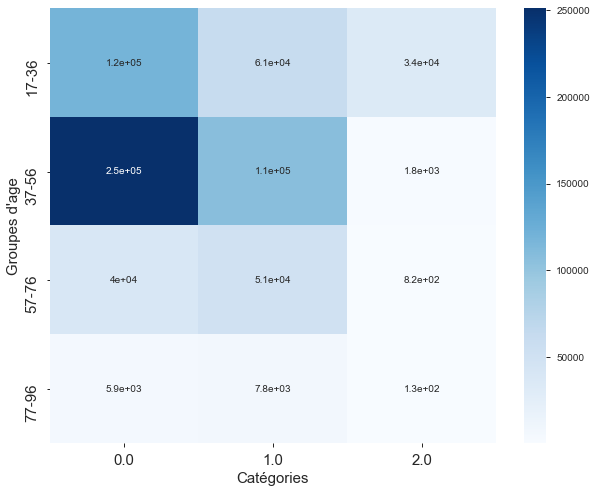

```python
plt.figure(figsize=(10,8))
sns.heatmap(trpcount1, annot=True, cmap="Blues")
plt.xticks(fontsize=15)
plt.yticks(fontsize=15)
plt.xlabel("Catégories",fontsize=15)
plt.ylabel("Groupes d'age",fontsize=15)
plt.show()
```

# Anova sur le prix et la catégorie

Dans une ANOVA, on cherche à déterminer si les moyennes des groupes sont significativement différentes.

On pose donc :

- H0 : Les moyennes de chaque groupe sont égales si p-value > 5%
- H1 : Les moyennes de chaque groupe ne sont pas toutes égales si p-value < 5%

```python
X = "categ" # qualitative
Y = "price" # quantitative
```

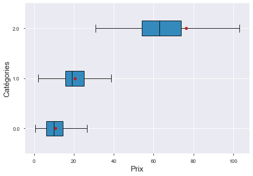

```python
modalites = trp6[X].unique()
groupes = []
for m in modalites:
    groupes.append(trp6[trp6[X]==m][Y])


medianprops = {'color':"black"}
meanprops = {'marker':'o', 'markeredgecolor':'black',
            'markerfacecolor':'firebrick'}

plt.boxplot(groupes, labels=modalites, showfliers=False, medianprops=medianprops,
            vert=False, patch_artist=True, showmeans=True, meanprops=meanprops)
plt.xlabel("Prix",fontsize=15)
plt.ylabel("Catégories",fontsize=15)
plt.show()
```

```python
from scipy.stats import f_oneway
F, p = f_oneway(trp6[trp6[X]==0]['price'],
               trp6[trp6[X]==1]['price'],
               trp6[trp6[X]==2]['price'])
print(f'la F-valeur vaut {F:.2f} et la p-valeur vaut {p}.')
```

```
la F-valeur vaut 618843.53 et la p-valeur vaut 0.0.
```

```python
def eta_squared(x,y):
    moyenne_y = y.mean()
    classes = []
    for classe in x.unique():
        yi_classe = y[x==classe]
        classes.append({'ni': len(yi_classe),
                        'moyenne_classe': yi_classe.mean()})
    SCT = sum([(yj-moyenne_y)**2 for yj in y])
    SCE = sum([c['ni']*(c['moyenne_classe']-moyenne_y)**2 for c in classes])
    return SCE/SCT
```

```python
g=eta_squared(trp6[X],trp6[Y])
print(f'Le eta_squared vaut {g :.2f}.')
```

```
Le eta_squared vaut 0.65.
```

# Répartion des prix par catégorie

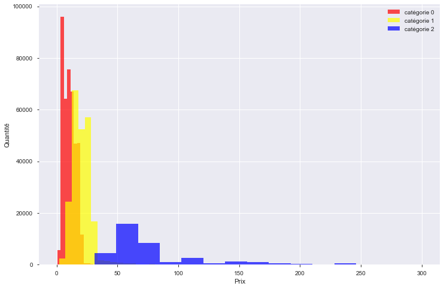

```python
plt.figure(figsize=(12,8))
trcat0=trp6[trp6['categ']==0]
trcat1=trp6[trp6['categ']==1]
trcat2=trp6[trp6['categ']==2]
plt.hist(trcat0.price, bins=15, alpha=0.7,color='red')
plt.hist(trcat1.price, bins=15, alpha=0.7,color='yellow')
plt.hist(trcat2.price, bins=15, alpha=0.7,color='blue')
plt.legend(['catégorie 0', 'catégorie 1', 'catégorie 2'])
plt.xlabel('Prix')
plt.ylabel('Quantité')
plt.show()
```

```python
print(trcat0['price'].mean(), trcat1['price'].mean() , trcat2['price'].mean())
```

```
10.644152443595448 20.48572952301662 76.2074122194194
```

- Moyenne des prix pour la catégorie 0 = 11 €
- Moyenne des prix pour la catégorie 1 = 20 €
- Moyenne des prix pour la catégorie 2 = 76 €

# Anova sur l'age et la catégorie

Dans une ANOVA, on cherche à déterminer si les moyennes des groupes sont significativement différentes.

On pose donc :

- H0 : Les moyennes de chaque groupe sont égales si p-value > 5%
- H1 : Les moyennes de chaque groupe ne sont pas toutes égales si p-value < 5%

```python
X = "categ" # qualitative
B = "Age" # quantitative
```

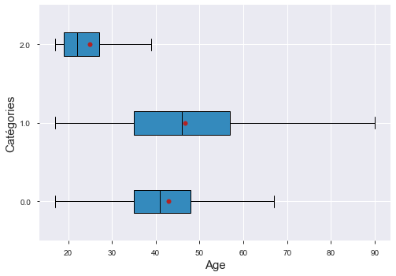

```python
modalites = trp6[X].unique()
groupes = []
for m in modalites:
    groupes.append(trp6[trp6[X]==m][B])


medianprops = {'color':"black"}
meanprops = {'marker':'o', 'markeredgecolor':'black',
            'markerfacecolor':'firebrick'}

plt.boxplot(groupes, labels=modalites, showfliers=False, medianprops=medianprops,
            vert=False, patch_artist=True, showmeans=True, meanprops=meanprops)
plt.xlabel("Age",fontsize=15)
plt.ylabel("Catégories",fontsize=15)
plt.show()
```

```python
from scipy.stats import f_oneway
F, p = f_oneway(trp6[trp6[X]==0][B],
               trp6[trp6[X]==1][B],
               trp6[trp6[X]==2][B])
print(f'la F-valeur vaut {F:.2f} et la p-valeur vaut {p}.')
```

```
la F-valeur vaut 45883.78 et la p-valeur vaut 0.0.
```

```python
n=eta_squared(trp6[X],trp6[B])
print(f'Le eta_squared vaut {n :.2f}.')
```

```
Le eta_squared vaut 0.12.
```

# Courbes de lorenz pour les clients

```python
trp10=trp6.groupby(['client_id']).sum().sort_values(by='price',ascending=True).reset_index()
```

```python
trp18=trp6.groupby(['client_id']).count().sort_values(by='price',ascending=True).reset_index()
```

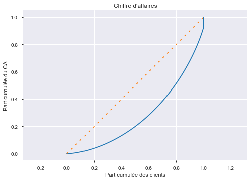

```python
ca=trp10['price'].values
n=len(ca)
lorenz = np.cumsum(np.sort(ca)) / ca.sum()
lorenz = np.append([0],lorenz)


plt.axes().axis('equal')
xaxis = np.linspace(0-1/n,1+1/n,n+1) #Il y a un segment de taille n pour chaque individu, plus 1 segment supplémentaire d'ordonnée 0. Le premier segment commence à 0-1/n, et le dernier termine à 1+1/n.
plt.plot(xaxis,lorenz,drawstyle='steps-post')
plt.plot(np.linspace(0,1,len(lorenz)), np.linspace(0,1,len(lorenz)), dashes=[2,5])
plt.ylabel('Part cumulée du CA')
plt.xlabel('Part cumulée des clients')
plt.title("Chiffre d'affaires")
plt.show()
```

gini = 0.45

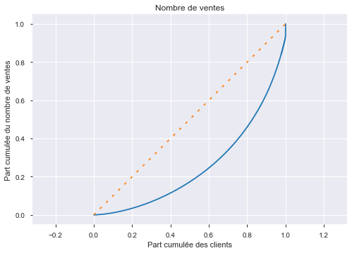

```python
nbv=trp18['price'].values
n=len(nbv)
lorenz3 = np.cumsum(np.sort(nbv)) / nbv.sum()
lorenz3 = np.append([0],lorenz3)


plt.axes().axis('equal')
xaxis = np.linspace(0-1/n,1+1/n,n+1) #Il y a un segment de taille n pour chaque individu, plus 1 segment supplémentaire d'ordonnée 0. Le premier segment commence à 0-1/n, et le dernier termine à 1+1/n.
plt.plot(xaxis,lorenz3,drawstyle='steps-post')
plt.plot(np.linspace(0,1,len(lorenz3)), np.linspace(0,1,len(lorenz3)), dashes=[2,5])
plt.ylabel('Part cumulée du nombre de ventes')
plt.xlabel('Part cumulée des clients')
plt.title("Nombre de ventes")
plt.show()
```

gini = 0.50

```python
def TRAPEZE(n,f):
    tra=0
    for i in range(1,n):
        tra+=(f[i]+f[i+1])*(1/n)*(1/2)
    return tra
```

```python
TRAPEZE(8600,lorenz)
```

```
0.2767961746749409
```

```python
indice_Gini4=(0.5-TRAPEZE(len(ca),lorenz))*2
```

```python
indice_Gini4
```

```
0.4464076506501182
```

```python
indice_Gini3=(0.5-TRAPEZE(len(nbv),lorenz3))*2
```

```python
indice_Gini3
```

```
0.49817674226212993
```

# Evolution du CA par jour

```python
tr72=trp6.groupby(['date']).sum().reset_index()
```

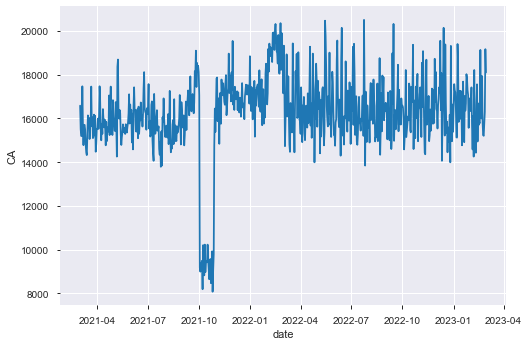

```python
plt.plot(tr72['date'],tr72['price'])
plt.xlabel("date")
plt.ylabel("CA")
plt.show()
```

# CA par mois

```python
ptr=tr72.groupby(pd.Grouper(key='date', freq='1M')).sum().reset_index()
```

```python
ptr=ptr.rename(columns={'price':'ca'})
```

```python
ptr['date']=ptr['date'].dt.strftime('%m-%Y')
```

```python
ptr[['date','ca']]
```

|  | date | ca |
| --- | --- | --- |
| 0 | 03-2021 | 482637.319772 |
| 1 | 04-2021 | 476415.292978 |
| 2 | 05-2021 | 493118.323131 |
| 3 | 06-2021 | 484241.556489 |
| 4 | 07-2021 | 482922.826565 |
| ... | ... | ... |
| 19 | 10-2022 | 508136.336413 |
| 20 | 11-2022 | 496905.363054 |
| 21 | 12-2022 | 510350.639848 |
| 22 | 01-2023 | 517693.546489 |
| 23 | 02-2023 | 456832.756489 |

```python
ptr['date']=pd.to_datetime(ptr['date'])
```

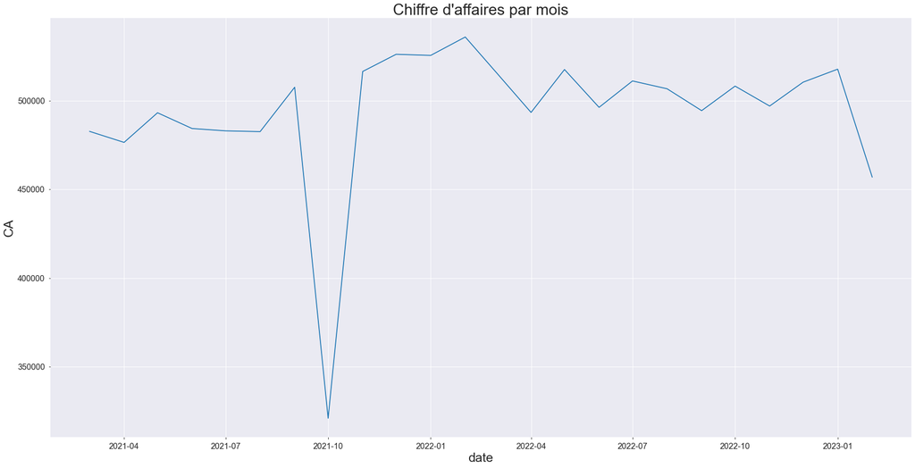

```python
plt.figure(figsize=(30,15))
plt.plot(ptr['date'],ptr['ca'])
plt.xticks(fontsize=16)
plt.yticks(fontsize=16)
plt.xlabel('date',fontsize=25)
plt.ylabel('CA',fontsize=25)
plt.title("Chiffre d'affaires par mois",fontsize=30)
plt.show()
```

```python
tr72=tr72.rename(columns={'price':'CA par date'})
```

# Pourcentage des ventes et pourcentage du CA par catégorie

```python
q=trp6[['categ','price']].groupby('categ').agg({'price':['count','sum']}).reset_index()
```

```python
q.columns = ['cat', 'nb_prod', 'ca']
```

```python
q
```

|  | cat | nb_prod | ca |
| --- | --- | --- | --- |
| 0 | 0.0 | 415680 | 4.424561e+06 |
| 1 | 1.0 | 227169 | 4.653723e+06 |
| 2 | 2.0 | 36483 | 2.780275e+06 |

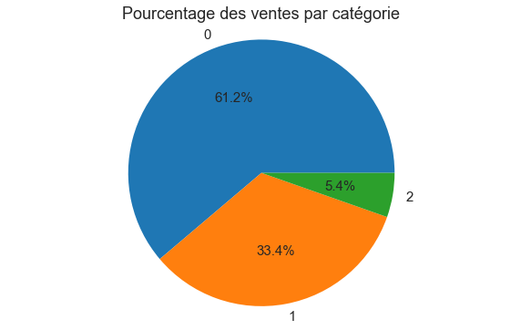

```python
plt.figure(figsize=(10,6))
plt.pie(q.nb_prod,autopct=lambda x:f'{x:.1f}%',labels=q.cat.index.values,textprops={'fontsize': 15})
plt.title('Pourcentage des ventes par catégorie',fontsize=18)
plt.axis('equal')
plt.show()
```

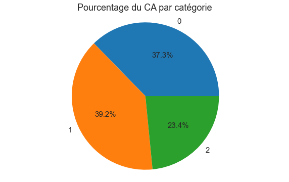

```python
plt.figure(figsize=(10,6))
plt.pie(q.ca, autopct=lambda x:f'{x:.1f}%',labels=q.cat.index.values,textprops={'fontsize': 15})
plt.axis('equal')
plt.title('Pourcentage du CA par catégorie',fontsize=18)
plt.show()
```

# Panier moyen

```python
sp=trp6.groupby('session_id').agg({'price':['count','sum']}).reset_index()
```

```python
sp.columns = ['session_id', 'nbprod', 'ca']
```

```python
sp.ca.mean()
```

```
34.64224178827313
```

Le panier moyen est de 34.6 euros.

```python
sp.ca.std()
```

```
32.59992956619137
```

# Produits vendus par session

```python
sp.nbprod.mean()
```

```
1.9845230270365015
```

Un client achéte en moyenne 2 produits par session.

```python
sp.nbprod.std()
```

```
1.27239200398095
```

# Test de pearson pour l'age et le panier moyen par age

```python
trp59=trp6.groupby(['client_id','Age',"groupe d'age"]).agg({'price':['count','sum']}).reset_index()
```

```python
trp59.columns = ['client_id', 'Age',"groupe d'age",'nbprod','ca']
```

```python
trp59=trp59.sort_values(by='ca',ascending=False)
```

```python
trp59
```

|  | client_id | Age | groupe d'age | nbprod | ca |
| --- | --- | --- | --- | --- | --- |
| 677 | c_1609 | 41 | 37-56 | 25488 | 324033.350000 |
| 4388 | c_4958 | 22 | 17-36 | 5195 | 289760.340000 |
| 6337 | c_6714 | 53 | 37-56 | 9187 | 153730.059848 |
| 2724 | c_3454 | 52 | 37-56 | 6773 | 113703.499924 |
| 2513 | c_3263 | 36 | 17-36 | 403 | 5276.870000 |
| ... | ... | ... | ... | ... | ... |
| 4044 | c_4648 | 17 | 17-36 | 1 | 11.200000 |
| 1556 | c_240 | 23 | 17-36 | 1 | 11.060000 |
| 7889 | c_8114 | 59 | 57-76 | 2 | 9.980000 |
| 7918 | c_8140 | 50 | 37-56 | 2 | 8.300000 |
| 8151 | c_8351 | 53 | 37-56 | 1 | 6.310000 |

```python
trp61=trp59.groupby(['Age']).sum()
```

```python
panier_m_age=trp61['ca']/trp61['nbprod']
```

```python
trp62=pd.concat([trp61,panier_m_age],axis=1).reset_index()
```

```python
trp63=trp62.rename(columns={0:'panier moyen'})
```

```python
trp63
```

|  | Age | nbprod | ca | panier moyen |
| --- | --- | --- | --- | --- |
| 0 | 17 | 15149 | 609013.690000 | 40.201577 |
| 1 | 18 | 4371 | 178195.780000 | 40.767737 |
| 2 | 19 | 4587 | 184242.919924 | 40.166322 |
| 3 | 20 | 4252 | 178497.700000 | 41.979704 |
| 4 | 21 | 4415 | 165051.693283 | 37.384302 |
| ... | ... | ... | ... | ... |
| 71 | 88 | 327 | 5276.206641 | 16.135189 |
| 72 | 89 | 311 | 5043.190000 | 16.216045 |
| 73 | 90 | 170 | 2815.450000 | 16.561471 |
| 74 | 91 | 226 | 4013.870000 | 17.760487 |
| 75 | 92 | 201 | 3221.850000 | 16.029104 |

On pose les hypothèses de départ :

- H0 : Variables indépendantes si p-value > 5%
- H1 : Variables non indépendantes si p-value < 5%

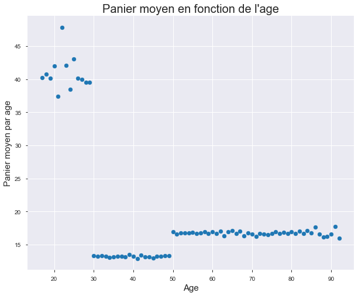

```python
plt.figure(figsize=(10,8))
plt.scatter(trp63['Age'],trp63['panier moyen'])
plt.xlabel("Age",fontsize=15)
plt.ylabel("Panier moyen par age",fontsize=15)
plt.title("Panier moyen en fonction de l'age",fontsize=20)
plt.show()
```

```python
Coeff,p=pearsonr(trp63["Age"],trp63['panier moyen'])
print(f'Le coefficient de corrélation vaut {Coeff:.2f} et la p-valeur vaut {p}.')
```

```
Le coefficient de corrélation vaut -0.55 et la p-valeur vaut 3.0164573002310094e-07.
```

# Anova sur le groupe d'age et le panier moyen

```python
trp59
```

|  | client_id | Age | groupe d'age | nbprod | ca |
| --- | --- | --- | --- | --- | --- |
| 677 | c_1609 | 41 | 37-56 | 25488 | 324033.350000 |
| 4388 | c_4958 | 22 | 17-36 | 5195 | 289760.340000 |
| 6337 | c_6714 | 53 | 37-56 | 9187 | 153730.059848 |
| 2724 | c_3454 | 52 | 37-56 | 6773 | 113703.499924 |
| 2513 | c_3263 | 36 | 17-36 | 403 | 5276.870000 |
| ... | ... | ... | ... | ... | ... |
| 4044 | c_4648 | 17 | 17-36 | 1 | 11.200000 |
| 1556 | c_240 | 23 | 17-36 | 1 | 11.060000 |
| 7889 | c_8114 | 59 | 57-76 | 2 | 9.980000 |
| 7918 | c_8140 | 50 | 37-56 | 2 | 8.300000 |
| 8151 | c_8351 | 53 | 37-56 | 1 | 6.310000 |

Dans une ANOVA, on cherche à déterminer si les moyennes des groupes sont significativement différentes.

On pose donc :

- H0 : Les moyennes de chaque groupe sont égales si p-value > 5%
- H1 : Les moyennes de chaque groupe ne sont pas toutes égales si p-value < 5%

```python
pmoyen=trp59['ca']/trp59['nbprod']
```

```python
tr54=pd.concat([trp59,pmoyen],axis=1)
```

```python
tr54=tr54.rename(columns={0:'panier moyen par client'})
```

```python
tr54
```

|  | client_id | Age | groupe d'age | nbprod | ca | panier moyen par client |
| --- | --- | --- | --- | --- | --- | --- |
| 677 | c_1609 | 41 | 37-56 | 25488 | 324033.350000 | 12.713173 |
| 4388 | c_4958 | 22 | 17-36 | 5195 | 289760.340000 | 55.776774 |
| 6337 | c_6714 | 53 | 37-56 | 9187 | 153730.059848 | 16.733434 |
| 2724 | c_3454 | 52 | 37-56 | 6773 | 113703.499924 | 16.787760 |
| 2513 | c_3263 | 36 | 17-36 | 403 | 5276.870000 | 13.093970 |
| ... | ... | ... | ... | ... | ... | ... |
| 4044 | c_4648 | 17 | 17-36 | 1 | 11.200000 | 11.200000 |
| 1556 | c_240 | 23 | 17-36 | 1 | 11.060000 | 11.060000 |
| 7889 | c_8114 | 59 | 57-76 | 2 | 9.980000 | 4.990000 |
| 7918 | c_8140 | 50 | 37-56 | 2 | 8.300000 | 4.150000 |
| 8151 | c_8351 | 53 | 37-56 | 1 | 6.310000 | 6.310000 |

```python
C="groupe d'age"
E="panier moyen par client"
```

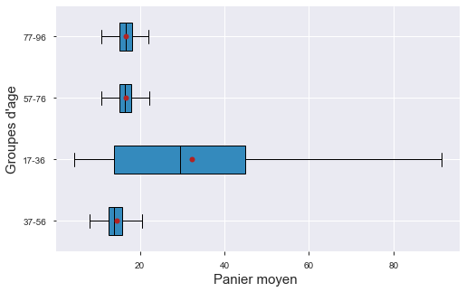

```python
modalites = tr54[C].unique()
groupes = []
for m in modalites:
    groupes.append(tr54[tr54[C]==m][E])


medianprops = {'color':"black"}
meanprops = {'marker':'o', 'markeredgecolor':'black',
            'markerfacecolor':'firebrick'}

plt.figure(figsize=(8,5))
plt.boxplot(groupes, labels=modalites, showfliers=False, medianprops=medianprops,
            vert=False, patch_artist=True, showmeans=True, meanprops=meanprops)
plt.xlabel("Panier moyen ",fontsize=15)
plt.ylabel("Groupes d'age",fontsize=15)
plt.show()
```

```python
from scipy.stats import f_oneway
F, p = f_oneway(tr54[tr54[C]=='17-36'][E],
                tr54[tr54[C]=='37-56'][E],
                tr54[tr54[C]=='57-76'][E],
                tr54[tr54[C]=='77-96'][E])

print(f'la F-valeur vaut {F:.2f} et la p-valeur vaut {p}.')
```

```
la F-valeur vaut 1289.71 et la p-valeur vaut 0.0.
```

```python
d=eta_squared(tr54[C],tr54[E])
print(f'Le eta_squared vaut {d:.2f}.')
```

```
Le eta_squared vaut 0.31.
```

# Test de Pearson pour le chiffre d'affaires et l'age

On pose les hypothèses de départ :

- H0 : Variables indépendantes si p-value > 5%
- H1 : Variables non indépendantes si p-value < 5%

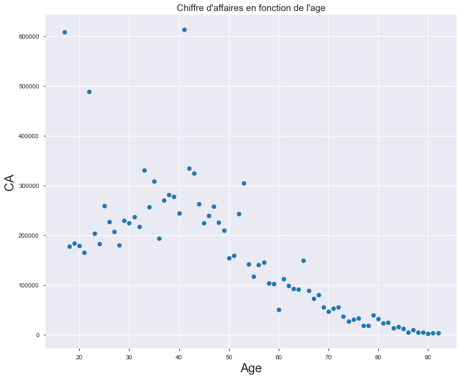

```python
plt.figure(figsize=(12,10))
plt.scatter(trp63['Age'],trp63['ca'])
plt.xlabel('Age',fontsize=20)
plt.ylabel('CA',fontsize=20)
plt.title("Chiffre d'affaires en fonction de l'age",fontsize=15)
plt.show()
```

```python
Coeff,p=pearsonr(trp63['ca'],trp63['Age'])
print(f'Le coefficient de corrélation vaut {Coeff:.2f} et la p-valeur vaut {p}.')
```

```
Le coefficient de corrélation vaut -0.78 et la p-valeur vaut 1.2025149766431946e-16.
```

# Anova entre le groupe d'age et le chiffre d'affaires

Dans une ANOVA, on cherche à déterminer si les moyennes des groupes sont significativement différentes.

On pose donc :

- H0 : Les moyennes de chaque groupe sont égales si p-value > 5%
- H1 : Les moyennes de chaque groupe ne sont pas toutes égales si p-value < 5%

```python
C="groupe d'age"
F="ca"
```

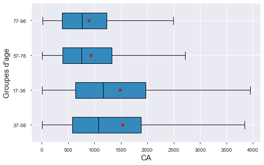

```python
modalites = trp59[C].unique()
groupes = []
for m in modalites:
    groupes.append(trp59[trp59[C]==m][F])


medianprops = {'color':"black"}
meanprops = {'marker':'o', 'markeredgecolor':'black',
            'markerfacecolor':'firebrick'}

plt.figure(figsize=(8,5))
plt.boxplot(groupes, labels=modalites, showfliers=False, medianprops=medianprops,
            vert=False, patch_artist=True, showmeans=True, meanprops=meanprops)
plt.xlabel("CA",fontsize=15)
plt.ylabel("Groupes d'age",fontsize=15)
plt.show()
```

```python
from scipy.stats import f_oneway
F, p = f_oneway(trp59[trp59[C]=='17-36'][F],
               trp59[trp59[C]=='37-56'][F],
               trp59[trp59[C]=='57-76'][F],
                trp59[trp59[C]=='77-96'][F])

print(f'la F-valeur vaut {F:.2f} et la p-valeur vaut {p}.')
```

```
la F-valeur vaut 6.29 et la p-valeur vaut 0.00029278578854123404.
```

```python
r=eta_squared(trp59["groupe d'age"],trp59['ca'])
print(f'Le eta_squared vaut {r}.')
```

```
Le eta_squared vaut 0.002191055818755758.
```

# Chiffre d'affaires et nombre de ventes par groupe d'age

```python
trp68=trp6.groupby(["groupe d'age"]).agg({'price':['count','sum']}).reset_index()
```

```python
trp68.columns=["groupe d'age",'nbventes','CA']
```

```python
trp68
```

|  | groupe d'age | nbventes | CA |
| --- | --- | --- | --- |
| 0 | 17-36 | 213655 | 5.065297e+06 |
| 1 | 37-56 | 360725 | 5.033385e+06 |
| 2 | 57-76 | 91110 | 1.527102e+06 |
| 3 | 77-96 | 13842 | 2.327755e+05 |

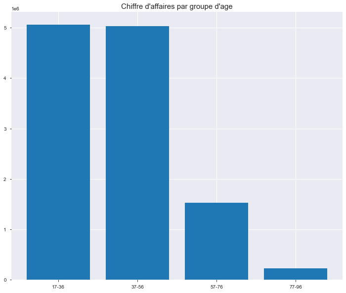

```python
plt.figure(figsize=(12,10))
plt.bar(trp68["groupe d'age"],trp68['CA'])
plt.title("Chiffre d'affaires par groupe d'age",fontsize=15)
plt.show()
```

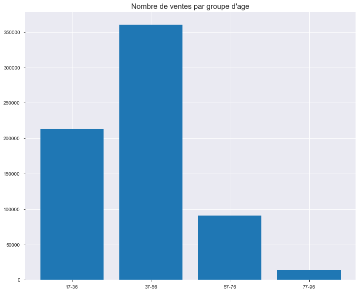

```python
plt.figure(figsize=(12,10))
plt.bar(trp68["groupe d'age"],trp68['nbventes'])
plt.title("Nombre de ventes par groupe d'age",fontsize=15)
plt.show()
```

# Chiffre d'affaires et nombre de ventes par groupe d'age pour chaque catégorie

```python
trp69=pd.pivot_table(trp6[['categ','price',"groupe d'age"]], index="groupe d'age", columns=['categ'], aggfunc=['sum','count']).reset_index()
```

```python
trp69.columns=['groupe age','0ca','1ca','2ca','0ve','1ve','2ve']
```

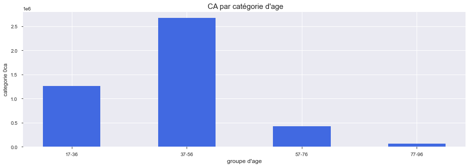

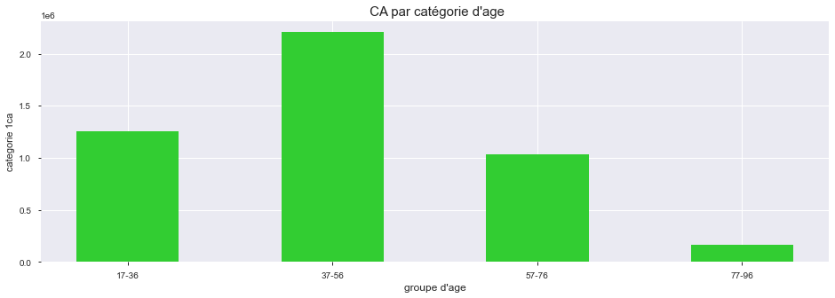

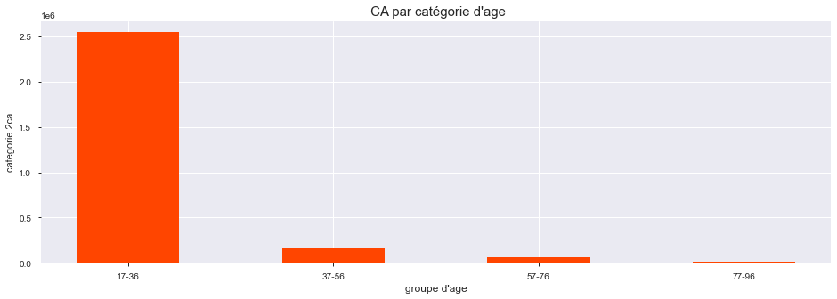

```python
color=['royalblue', 'limegreen', 'orangered']
for i, categ in enumerate(['0ca','1ca','2ca']):
    plt.figure(figsize=(35,5))
    plt.subplot(1,2,2)
    plt.bar(trp69["groupe age"], trp69[categ], width=0.5, color=color[i])
    plt.xlabel("groupe d'age",fontsize=12)
    plt.ylabel(f'categorie {categ}')
    plt.title(" CA par catégorie d'age",fontsize=15)
    plt.show()
```

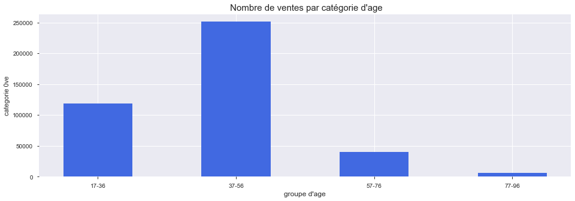

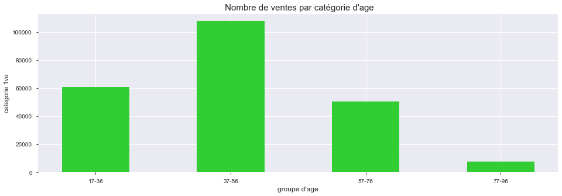

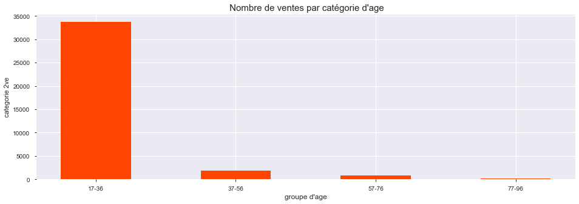

```python
color=['royalblue', 'limegreen', 'orangered']
for i, categ in enumerate(['0ve','1ve','2ve']):
    plt.figure(figsize=(35,5))
    plt.subplot(1,2,2)
    plt.bar(trp69["groupe age"], trp69[categ], width=0.5, color=color[i])
    plt.xlabel("groupe d'age",fontsize=12)
    plt.ylabel(f'categorie {categ}')
    plt.title(" Nombre de ventes par catégorie d'age",fontsize=15)
    plt.show()
```

# CA et nombre de ventes par genre et groupe d'age

```python
tr8=trp6[["groupe d'age",'sex','price']].groupby(["groupe d'age",'sex']).agg({'price':['count','sum']}).reset_index()
```

```python
tr8
```

|  | groupe d'age | sex | price count | price sum |
| --- | --- | --- | --- | --- |
| 0 | 17-36 | f | 104946 | 2.427178e+06 |
| 1 | 17-36 | m | 108709 | 2.638119e+06 |
| 2 | 37-56 | f | 177962 | 2.503284e+06 |
| 3 | 37-56 | m | 182763 | 2.530101e+06 |
| 4 | 57-76 | f | 47874 | 8.021309e+05 |
| 5 | 57-76 | m | 43236 | 7.249713e+05 |
| 6 | 77-96 | f | 7620 | 1.296477e+05 |
| 7 | 77-96 | m | 6222 | 1.031277e+05 |

```python
tr8.columns=['groupe age','sex','nbventes','ca']
```

```python
tr8
```

|  | groupe age | sex | nbventes | ca |
| --- | --- | --- | --- | --- |
| 0 | 17-36 | f | 104946 | 2.427178e+06 |
| 1 | 17-36 | m | 108709 | 2.638119e+06 |
| 2 | 37-56 | f | 177962 | 2.503284e+06 |
| 3 | 37-56 | m | 182763 | 2.530101e+06 |
| 4 | 57-76 | f | 47874 | 8.021309e+05 |
| 5 | 57-76 | m | 43236 | 7.249713e+05 |
| 6 | 77-96 | f | 7620 | 1.296477e+05 |
| 7 | 77-96 | m | 6222 | 1.031277e+05 |

```python
tr9=pd.pivot_table(tr8,index='groupe age', columns=['sex'], aggfunc=['sum']).reset_index()
```

```python
tr9
```

| sex | groupe age | sum ca f | sum ca m | sum nbventes f | sum nbventes m |
| --- | --- | --- | --- | --- | --- |
| 0 | 17-36 | 2.427178e+06 | 2.638119e+06 | 104946 | 108709 |
| 1 | 37-56 | 2.503284e+06 | 2.530101e+06 | 177962 | 182763 |
| 2 | 57-76 | 8.021309e+05 | 7.249713e+05 | 47874 | 43236 |
| 3 | 77-96 | 1.296477e+05 | 1.031277e+05 | 7620 | 6222 |

```python
tr9.columns=['groupe age','fca','mca','fve','mve']
```

```python
tr9
```

|  | groupe age | fca | mca | fve | mve |
| --- | --- | --- | --- | --- | --- |
| 0 | 17-36 | 2.427178e+06 | 2.638119e+06 | 104946 | 108709 |
| 1 | 37-56 | 2.503284e+06 | 2.530101e+06 | 177962 | 182763 |
| 2 | 57-76 | 8.021309e+05 | 7.249713e+05 | 47874 | 43236 |
| 3 | 77-96 | 1.296477e+05 | 1.031277e+05 | 7620 | 6222 |

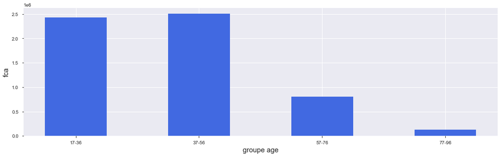

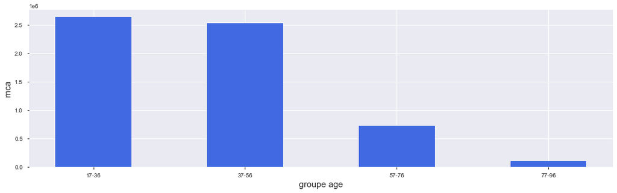

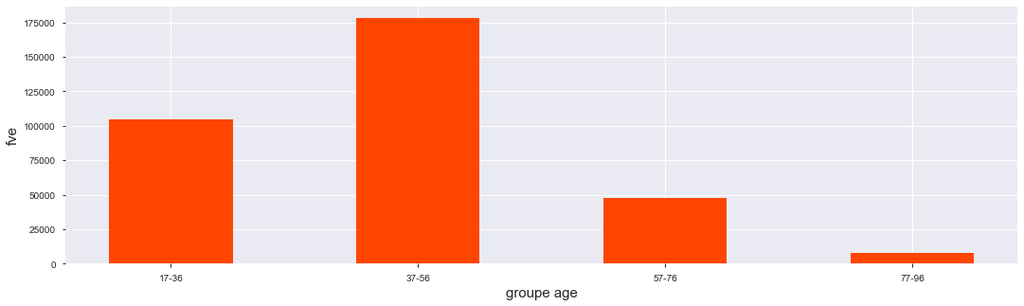

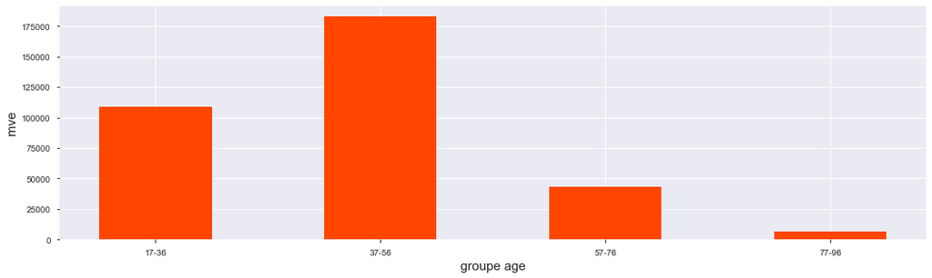

```python
color=['royalblue', 'royalblue','orangered','orangered']
for i, genre in enumerate(['fca','mca','fve','mve']):
    plt.figure(figsize=(18,5))
    plt.bar(tr9['groupe age'], tr9[genre], width=0.5, color=color[i])
    plt.xlabel("groupe age",fontsize=15)
    plt.ylabel(f'{genre}',fontsize=15)
    plt.show()
```

# CA et nombre de ventes par genre , catégories et groupe d'age

```python
tr18=trp6[["groupe d'age",'sex','price','categ']].groupby(["groupe d'age",'sex','categ']).agg({'price':['count','sum']}).reset_index()
```

```python
tr18.columns=['groupe age','sex','categ','nbventes','ca']
```

```python
tr18
```

|  | groupe age | sex | categ | nbventes | ca |
| --- | --- | --- | --- | --- | --- |
| 0 | 17-36 | f | 0.0 | 59217 | 6.297210e+05 |
| 1 | 17-36 | f | 1.0 | 30046 | 6.169479e+05 |
| 2 | 17-36 | f | 2.0 | 15683 | 1.180509e+06 |
| 3 | 17-36 | m | 0.0 | 59705 | 6.373548e+05 |
| 4 | 17-36 | m | 1.0 | 30991 | 6.340102e+05 |
| ... | ... | ... | ... | ... | ... |
| 19 | 77-96 | f | 1.0 | 4375 | 9.015243e+04 |
| 20 | 77-96 | f | 2.0 | 79 | 5.615510e+03 |
| 21 | 77-96 | m | 0.0 | 2743 | 2.920086e+04 |
| 22 | 77-96 | m | 1.0 | 3425 | 7.006374e+04 |
| 23 | 77-96 | m | 2.0 | 54 | 3.863140e+03 |

```python
tr19=pd.pivot_table(tr18,index='groupe age', columns=['sex','categ'], aggfunc=['sum']).reset_index()
```

```python
tr19.columns=['groupe age','0fca','1fca','2fca','0mca','1mca','2mca','0fve','1fve','2fve','0mve','1mve','2mve']
```

```python
tr19
```

|  | groupe age | 0fca | 1fca | 2fca | 0mca | 1mca | 2mca | 0fve | 1fve | 2fve | 0mve | 1mve | 2mve |
| --- | --- | --- | --- | --- | --- | --- | --- | --- | --- | --- | --- | --- | --- |
| 0 | 17-36 | 6.297210e+05 | 616947.93 | 1180509.13 | 6.373548e+05 | 634010.25 | 1366753.61 | 59217 | 30046 | 15683 | 59705 | 30991 | 18013 |
| 1 | 37-56 | 1.308475e+06 | 1103519.15 | 91289.67 | 1.362650e+06 | 1101876.82 | 65573.95 | 123108 | 53733 | 1121 | 128079 | 53976 | 708 |
| 2 | 57-76 | 2.204946e+05 | 547797.51 | 33838.73 | 2.027851e+05 | 489354.86 | 32831.28 | 20729 | 26745 | 400 | 18933 | 23878 | 425 |
| 3 | 77-96 | 3.387979e+04 | 90152.43 | 5615.51 | 2.920086e+04 | 70063.74 | 3863.14 | 3166 | 4375 | 79 | 2743 | 3425 | 54 |

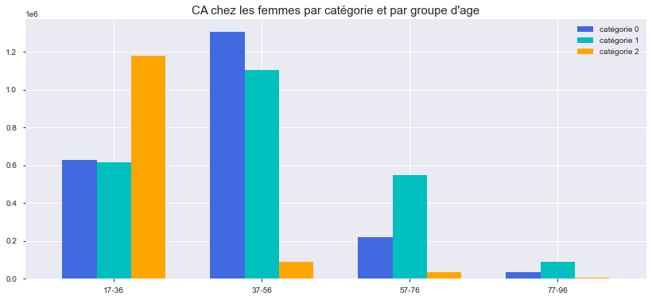

```python
values=['17-36','37-56','57-76','77-96']
tr19[['0fca','1fca','2fca']].plot.bar(figsize=(14,6),  width=0.7,  color=['royalblue', 'c', 'orange'])
plt.legend(['catégorie 0', 'catégorie 1', 'catégorie 2'])
plt.title("CA chez les femmes par catégorie et par groupe d'age",fontsize=15)
plt.xticks([0,1,2,3],values,rotation=0)
plt.show()
```

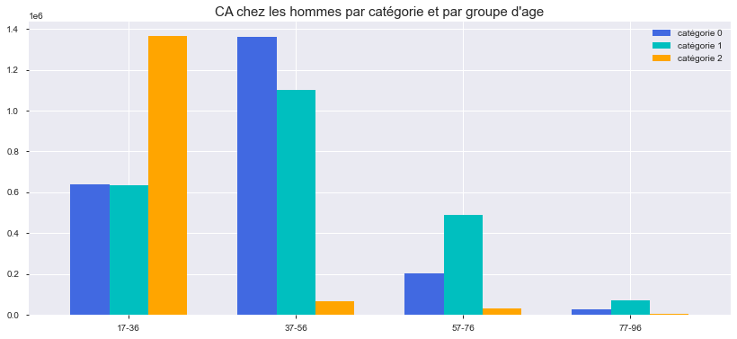

```python
tr19[['0mca','1mca','2mca']].plot.bar(figsize=(14,6),  width=0.7,  color=['royalblue', 'c', 'orange'])
plt.legend(['catégorie 0', 'catégorie 1', 'catégorie 2'])
plt.title("CA chez les hommes par catégorie et par groupe d'age",fontsize=15)
plt.xticks([0,1,2,3],values,rotation=0)
plt.show()
```

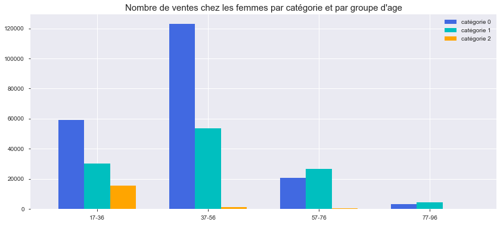

```python
tr19[['0fve','1fve','2fve']].plot.bar(figsize=(14,6),  width=0.7,  color=['royalblue', 'c', 'orange'])
plt.legend(['catégorie 0', 'catégorie 1', 'catégorie 2'])
plt.title("Nombre de ventes chez les femmes par catégorie et par groupe d'age",fontsize=15)
plt.xticks([0,1,2,3],values,rotation=0)
plt.show()
```

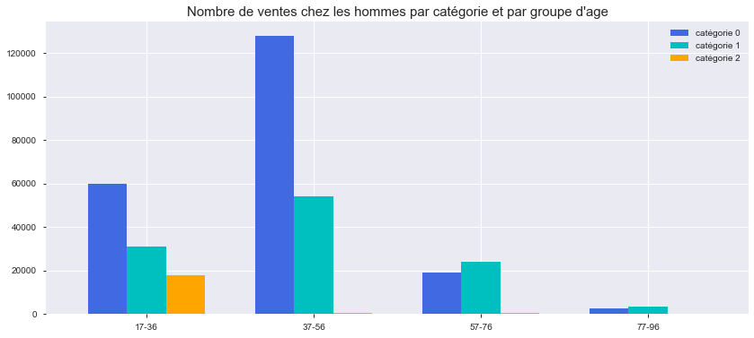

```python
tr19[['0mve','1mve','2mve']].plot.bar(figsize=(14,6),  width=0.7,  color=['royalblue', 'c', 'orange'])
plt.legend(['catégorie 0', 'catégorie 1', 'catégorie 2'])
plt.title("Nombre de ventes chez les hommes par catégorie et par groupe d'age",fontsize=15)
plt.xticks([0,1,2,3],values,rotation=0)
plt.show()
```

Le comportement des hommes et des femmes au niveau du nombre d'achats et du chiffre d'affaires selon les catégories est similaire.

# Répartition des achats par genre

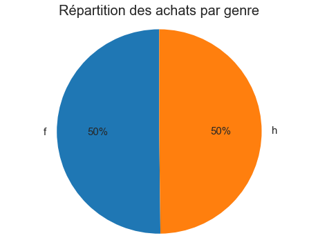

```python
plt.figure(figsize=(8,6))
plt.pie(trp6.sex.value_counts(), autopct=lambda x:f'{x:.0f}%',labels=['f', 'h'], textprops={'fontsize': 15},startangle=90)
plt.title("Répartition des achats par genre",fontsize=20)
plt.axis('equal')
plt.figure(figsize=(50,50))
plt.show()
```

# Répartition des clients par genre

```python
rp=pd.crosstab(trp6['client_id'],trp6['sex'])
```

```python
rp[rp['f']!=0].shape[0]
```

```
4479
```

```python
rp[rp['m']!=0].shape[0]
```

```
4121
```

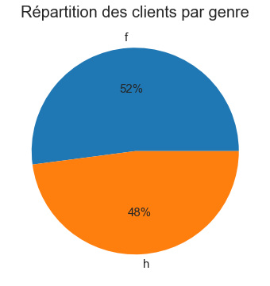

```python
plt.figure(figsize=(10,6))
liste=[rp[rp['f']!=0].shape[0],rp[rp['m']!=0].shape[0]]
genre=['f','h']
plt.pie(liste,labels=genre,autopct=lambda x:f'{x:.0f}%',textprops={'fontsize': 15})
plt.title("Répartition des clients par genre",fontsize=20)
plt.show()
```

On peut voir qu'il y a une parité parmi les clients.

# Répartition par age des achats

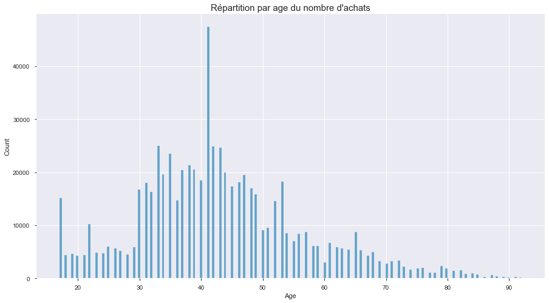

```python
plt.figure(figsize=(15,8))
sns.histplot(trp6["Age"])
plt.title("Répartition par age du nombre d'achats",fontsize=15)
plt.show()
```

```python
trp6['Age'].describe()
```

```
count    679332.000000
mean         43.188861
std          13.574553
min          17.000000
25%          34.000000
50%          41.000000
75%          51.000000
max          92.000000
Name: Age, dtype: float64
```

L'age moyen des acheteurs est de 43 ans.

# Répartition par age des clients

```python
trp625=trp6.groupby(['client_id','Age']).count().reset_index()[['client_id','Age']]
```

```python
trp626=trp625.groupby('Age').count()
```

```python
trp626.columns=['Nombre clients par age']
```

```python
trp627=trp626.reset_index()
```

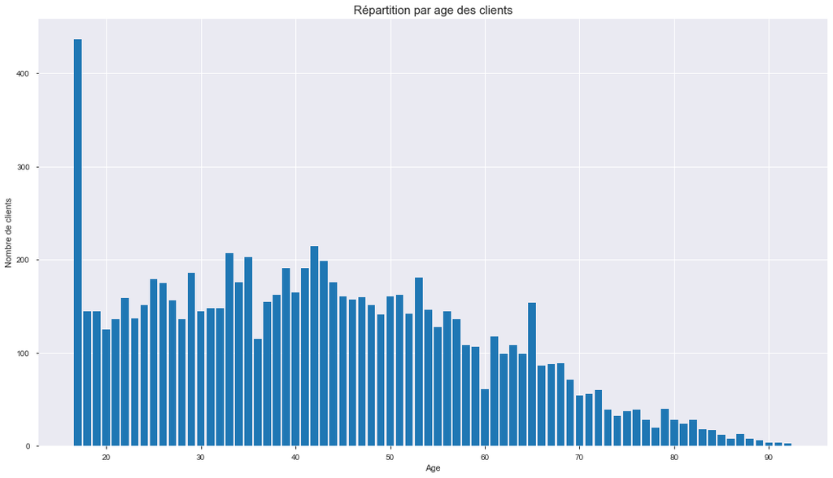

```python
plt.figure(figsize=(18,10))
plt.bar(trp627['Age'],trp627['Nombre clients par age'])
plt.xlabel("Age")
plt.ylabel("Nombre de clients")
plt.title('Répartition par age des clients',fontsize=15)
plt.show()
```

Un nombre important de clients de 17 ans.

# Courbes de lorenz pour les produits

```python
trp78=trp6.groupby(['id_prod']).agg({'price':'count'}).reset_index().sort_values(by='price',ascending=True)
```

```python
trp78.columns=['id_prod','nb_ventes']
```

```python
trp78
```

|  | id_prod | nb_ventes |
| --- | --- | --- |
| 1793 | 0_549 | 1 |
| 1327 | 0_2201 | 1 |
| 3176 | 2_23 | 1 |
| 313 | 0_1284 | 1 |
| 752 | 0_1683 | 1 |
| ... | ... | ... |
| 2654 | 1_425 | 2096 |
| 2734 | 1_498 | 2128 |
| 2642 | 1_414 | 2180 |
| 2645 | 1_417 | 2189 |
| 2592 | 1_369 | 2252 |

```python
trp78.columns=['id_prod','nbprod']
```

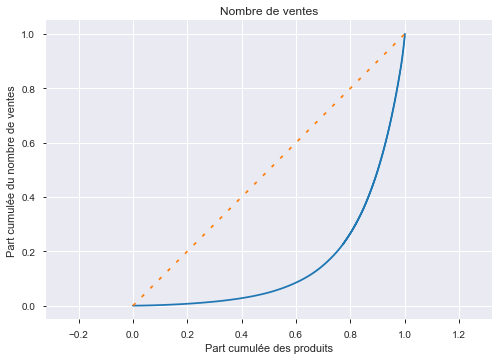

```python
nbventes=trp78['nbprod'].values
n=len(nbventes)
lorenz1 = np.cumsum(np.sort(nbventes)) / nbventes.sum()
lorenz1 = np.append([0],lorenz1)


plt.axes().axis('equal')
xaxis = np.linspace(0-1/n,1+1/n,n+1) #Il y a un segment de taille n pour chaque individu, plus 1 segment supplémentaire d'ordonnée 0. Le premier segment commence à 0-1/n, et le dernier termine à 1+1/n.
plt.plot(xaxis,lorenz1,drawstyle='steps-post')
plt.plot(np.linspace(0,1,len(lorenz1)), np.linspace(0,1,len(lorenz1)), dashes=[2,5])
plt.ylabel('Part cumulée du nombre de ventes')
plt.xlabel('Part cumulée des produits')
plt.title("Nombre de ventes")
plt.show()
```

gini = 0.69

```python
TRAPEZE(len(nbventes),lorenz1)
```

```
0.15317106370971964
```

```python
indice_Gini2=(0.5-TRAPEZE(len(nbventes),lorenz1))*2
```

```python
indice_Gini2
```

```
0.6936578725805607
```

```python
trp79=trp6.groupby(['id_prod']).agg({'price':'sum'}).reset_index().sort_values(by='price',ascending=True)
```

```python
trp79.columns=['id_prod','CA du produit']
```

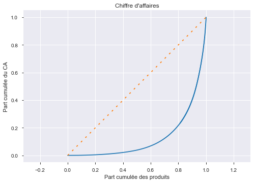

```python
CA=trp79['CA du produit'].values
n=len(CA)
lorenz2 = np.cumsum(np.sort(CA)) / CA.sum()
lorenz2 = np.append([0],lorenz2)


plt.axes().axis('equal')
xaxis = np.linspace(0-1/n,1+1/n,n+1) #Il y a un segment de taille n pour chaque individu, plus 1 segment supplémentaire d'ordonnée 0. Le premier segment commence à 0-1/n, et le dernier termine à 1+1/n.
plt.plot(xaxis,lorenz2,drawstyle='steps-post')
plt.plot(np.linspace(0,1,len(lorenz2)), np.linspace(0,1,len(lorenz2)), dashes=[2,5])
plt.ylabel('Part cumulée du CA')
plt.xlabel('Part cumulée des produits')
plt.title("Chiffre d'affaires")
plt.show()
```

gini = 0.74

```python
indice_Gini1=(0.5-TRAPEZE(len(CA),lorenz2))*2
```

```python
indice_Gini1
```

```
0.7427855356542441
```

# Moyenne mobile du CA d'ordre 3

```python
tr73=tr72.set_index('date')
```

```python
moy_mob=tr73.resample("3M").mean()
```

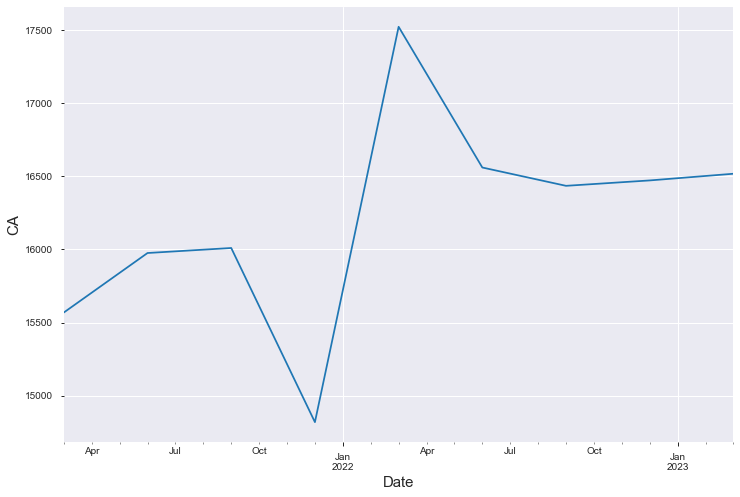

```python
plt.figure(figsize=(12,8))
moy_mob['CA par date'].plot()
plt.xlabel('Date',fontsize=15)
plt.ylabel('CA',fontsize=15)
plt.show()
```

# Calcul du CA total

```python
trp6
```

| date | id_prod | session_id | client_id | price | categ | sex | birth | Age | Year | Month | Day | groupe d'age |
| --- | --- | --- | --- | --- | --- | --- | --- | --- | --- | --- | --- | --- |
| 2022-05-20 | 0_1518 | s_211425 | c_103 | 4.18 | 0.0 | f | 1986 | 35 | 2022 | 5 | 20 | 17-36 |
| 2021-07-20 | 0_1518 | s_64849 | c_103 | 4.18 | 0.0 | f | 1986 | 35 | 2021 | 7 | 20 | 17-36 |
| 2022-08-20 | 0_1518 | s_255965 | c_103 | 4.18 | 0.0 | f | 1986 | 35 | 2022 | 8 | 20 | 17-36 |
| 2022-06-18 | 0_1418 | s_225411 | c_103 | 8.57 | 0.0 | f | 1986 | 35 | 2022 | 6 | 18 | 17-36 |
| 2021-08-18 | 0_1418 | s_77214 | c_103 | 8.57 | 0.0 | f | 1986 | 35 | 2021 | 8 | 18 | 17-36 |
| ... | ... | ... | ... | ... | ... | ... | ... | ... | ... | ... | ... | ... |
| 2021-07-23 | 2_147 | s_65994 | c_4391 | 181.99 | 2.0 | f | 2001 | 20 | 2021 | 7 | 23 | 17-36 |
| 2022-03-25 | 0_142 | s_184472 | c_1232 | 19.85 | 0.0 | f | 1960 | 61 | 2022 | 3 | 25 | 57-76 |
| 2021-09-25 | 0_142 | s_95415 | c_1232 | 19.85 | 0.0 | f | 1960 | 61 | 2021 | 9 | 25 | 57-76 |
| 2021-03-11 | 2_205 | s_4605 | c_7534 | 100.99 | 2.0 | m | 1992 | 29 | 2021 | 3 | 11 | 17-36 |
| 2022-07-11 | 2_205 | s_236636 | c_7534 | 100.99 | 2.0 | m | 1992 | 29 | 2022 | 7 | 11 | 17-36 |

```python
trp6['price'].sum()
```

```
11858558.997730454
```

Le CA total est de 11 858 559 € *.

# Evolution globale du chiffre d'affaires et du nombre de ventes dans le temps

```python
trp100=trp6.sort_values('date').reset_index()
```

```python
trp100['ca']=np.cumsum(trp100.price)
```

```python
trp100
```

|  | date | id_prod | session_id | client_id | price | categ | sex | birth | Age | Year | Month | Day | groupe d'age | ca |
| --- | --- | --- | --- | --- | --- | --- | --- | --- | --- | --- | --- | --- | --- | --- |
| 0 | 2021-03-01 | 2_62 | s_39 | c_184 | 60.96 | 2.0 | m | 2004 | 17 | 2021 | 3 | 1 | 17-36 | 6.096000e+01 |
| 1 | 2021-03-01 | 0_1967 | s_303 | c_3745 | 12.99 | 0.0 | f | 1991 | 30 | 2021 | 3 | 1 | 17-36 | 7.395000e+01 |
| 2 | 2021-03-01 | 0_1445 | s_485 | c_2156 | 9.99 | 0.0 | m | 1978 | 43 | 2021 | 3 | 1 | 37-56 | 8.394000e+01 |
| 3 | 2021-03-01 | 1_576 | s_303 | c_3745 | 17.20 | 1.0 | f | 1991 | 30 | 2021 | 3 | 1 | 17-36 | 1.011400e+02 |
| 4 | 2021-03-01 | 0_2215 | s_83 | c_7447 | 3.99 | 0.0 | m | 1987 | 34 | 2021 | 3 | 1 | 17-36 | 1.051300e+02 |
| ... | ... | ... | ... | ... | ... | ... | ... | ... | ... | ... | ... | ... | ... | ... |
| 679327 | 2023-02-28 | 0_1017 | s_348071 | c_4569 | 8.99 | 0.0 | f | 1955 | 66 | 2023 | 2 | 28 | 57-76 | 1.185846e+07 |
| 679328 | 2023-02-28 | 1_283 | s_347979 | c_7495 | 14.99 | 1.0 | m | 1982 | 39 | 2023 | 2 | 28 | 37-56 | 1.185847e+07 |
| 679329 | 2023-02-28 | 0_1393 | s_347979 | c_7495 | 11.99 | 0.0 | m | 1982 | 39 | 2023 | 2 | 28 | 37-56 | 1.185848e+07 |
| 679330 | 2023-02-28 | 1_87 | s_348312 | c_6218 | 58.99 | 1.0 | f | 1987 | 34 | 2023 | 2 | 28 | 17-36 | 1.185854e+07 |
| 679331 | 2023-02-28 | 0_1382 | s_348322 | c_7280 | 15.62 | 0.0 | m | 1980 | 41 | 2023 | 2 | 28 | 37-56 | 1.185856e+07 |

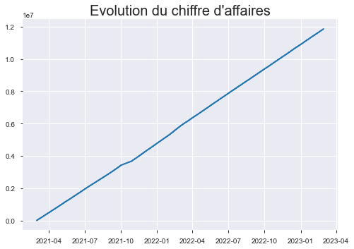

```python
plt.plot(trp100['date'],trp100['ca'])
plt.title("Evolution du chiffre d'affaires",fontsize=20)
plt.show()
```

```python
n=pd.Series(range(len(trp100)))+1
```

```python
n
```

```
0              1
1              2
2              3
3              4
4              5
           ...
679327    679328
679328    679329
679329    679330
679330    679331
679331    679332
Length: 679332, dtype: int64
```

```python
trp101=pd.concat([trp100,n],axis=1)
```

```python
trp101=trp101.rename(columns={0:'nbventes'})
```

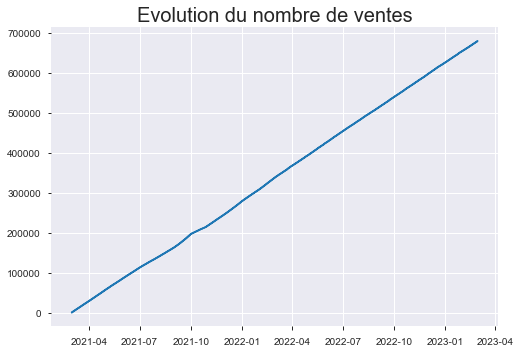

```python
plt.plot(trp101['date'],trp101['nbventes'])
plt.title("Evolution du nombre de ventes",fontsize=20)
plt.show()
```

# Evolution du nombre de ventes et du chiffre d'affaires mensuelles

```python
trp145=pd.crosstab(trp6['Month'], trp6['categ']).reset_index()
```

```python
trp145
```

| categ | Month | 0.0 | 1.0 | 2.0 |
| --- | --- | --- | --- | --- |
| 0 | 1 | 32477 | 22812 | 3004 |
| 1 | 2 | 32554 | 19248 | 3355 |
| 2 | 3 | 36196 | 19260 | 2861 |
| 3 | 4 | 35835 | 17081 | 3157 |
| 4 | 5 | 36933 | 18154 | 3197 |
| ... | ... | ... | ... | ... |
| 7 | 8 | 32395 | 18259 | 3557 |
| 8 | 9 | 40388 | 18834 | 2419 |
| 9 | 10 | 36443 | 11392 | 2745 |
| 10 | 11 | 31930 | 22114 | 2851 |
| 11 | 12 | 36250 | 22322 | 2517 |

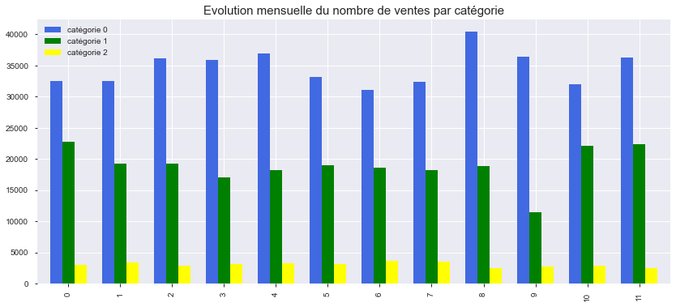

```python
trp145[[0, 1, 2]].plot.bar(figsize=(14,6),  width=0.7,  color=['royalblue', 'green', 'yellow'])
plt.legend(['catégorie 0', 'catégorie 1', 'catégorie 2'])
plt.title('Evolution mensuelle du nombre de ventes par catégorie',fontsize=15)
plt.show()
```

```python
trp148=trp6[['categ','price','Month']]
```

```python
trp149=pd.pivot_table(trp148, index='Month', columns=['categ'], aggfunc=['sum', 'count']).reset_index()
```

```python
trp149.columns = ['Month', '0ca', '1ca', '2ca', 'nbv0', 'nbv1', 'nbv2']
```

```python
trp149
```

|  | Month | 0ca | 1ca | 2ca | nbv0 | nbv1 | nbv2 |
| --- | --- | --- | --- | --- | --- | --- | --- |
| 0 | 1 | 345755.849696 | 466372.33 | 231013.64 | 32477 | 22812 | 3004 |
| 1 | 2 | 346047.749544 | 393467.88 | 253129.05 | 32554 | 19248 | 3355 |
| 2 | 3 | 385531.242826 | 393459.43 | 219343.60 | 36196 | 19260 | 2861 |
| 3 | 4 | 380831.705957 | 351402.32 | 237486.20 | 35835 | 17081 | 3157 |
| 4 | 5 | 391583.619391 | 371426.03 | 247590.98 | 36933 | 18154 | 3197 |
| ... | ... | ... | ... | ... | ... | ... | ... |
| 7 | 8 | 345481.942902 | 374351.47 | 269290.21 | 32395 | 18259 | 3557 |
| 8 | 9 | 430142.139467 | 385993.32 | 185678.74 | 40388 | 18834 | 2419 |
| 9 | 10 | 387051.562902 | 233371.98 | 208664.53 | 36443 | 11392 | 2745 |
| 10 | 11 | 340962.899468 | 453338.38 | 218990.38 | 31930 | 22114 | 2851 |
| 11 | 12 | 386791.076337 | 456972.46 | 192657.38 | 36250 | 22322 | 2517 |

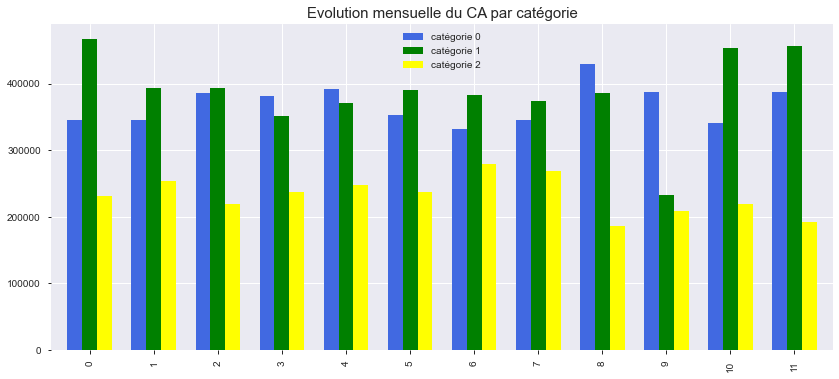

```python
trp149[['0ca', '1ca', '2ca']].plot.bar(
    figsize=(14,6),
    width=0.7,
    color=['royalblue', 'green', 'yellow']
)
plt.legend(['catégorie 0', 'catégorie 1', 'catégorie 2'])
plt.title('Evolution mensuelle du CA par catégorie',fontsize=15)
plt.show()
```

# Problème du mois d'octobre 2021

```python
trp89=trp6.reset_index()
```

```python
trp90=trp89[(trp89['date']>='2021-10-01') & (trp89['date']<='2021-10-31')].groupby(['categ','Day']).sum().reset_index()
```

```python
trp91=pd.pivot_table(trp90, columns=['categ'], index=['Day']).reset_index()
```

```python
trp92=trp91[['Day','price']]
```

```python
trp92.columns=['Day',0,1,2]
```

```python
trp92
```

|  | Day | 0 | 1 | 2 |
| --- | --- | --- | --- | --- |
| 0 | 1 | 6950.500000 | 7003.79 | 3104.05 |
| 1 | 2 | 7141.010000 | NaN | 2041.12 |
| 2 | 3 | 6786.570000 | NaN | 2206.48 |
| 3 | 4 | 6577.313283 | NaN | 2746.08 |
| 4 | 5 | 6357.910000 | NaN | 3032.55 |
| ... | ... | ... | ... | ... |
| 26 | 27 | 5822.240000 | NaN | 3967.29 |
| 27 | 28 | 5837.610000 | 6317.99 | 2602.82 |
| 28 | 29 | 6410.570000 | 6425.18 | 3617.88 |
| 29 | 30 | 5734.620000 | 6753.69 | 2898.47 |
| 30 | 31 | 5924.070000 | 7261.67 | 3219.38 |

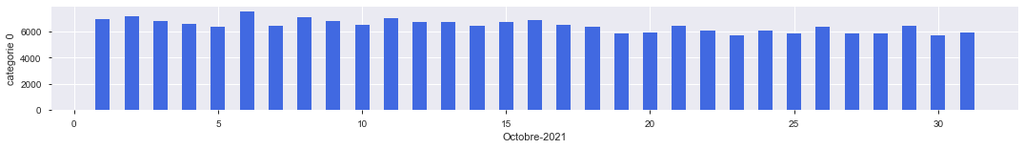

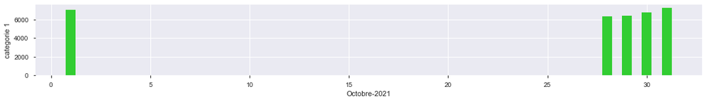

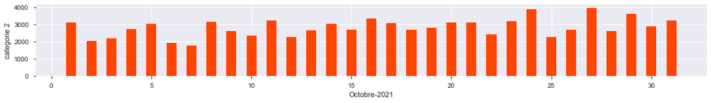

```python
color=['royalblue', 'limegreen', 'orangered']
for i, categ in enumerate([0,1,2]):
    plt.figure(figsize=(40,2))
    plt.subplot(1,2,2)
    plt.bar(trp92['Day'], trp92[categ], width=0.5, color=color[i])
    plt.xlabel("Octobre-2021")
    plt.ylabel(f'categorie {categ}')
    plt.show()
```

# Les produits

```python
trp295=trp89[['id_prod', 'price']].groupby('id_prod').agg({'price': ['count', 'sum']}).reset_index()
```

```python
trp295.columns=['id_prod','nbventes','CA']
```

```python
trp296=trp295.sort_values('CA',ascending=False)
```

```python
cumsumca=np.cumsum(trp296['CA'])
```

```python
trp297=pd.concat([trp296,cumsumca],axis=1)
```

```python
(trp297['id_prod'].unique().shape[0])/5
```

```
653.2
```

```python
trp297.columns=['id_prod','nbventes','CA','CA cumulé']
```

```python
trp297.shape
```

```
(3266, 4)
```

```python
(trp297.iloc[652]['CA cumulé']/trp297.iloc[3265]['CA cumulé'])*100
```

```
78.18773258626909
```

20 % des produits qui rapportent le plus d'argent représente 78 % du chiffre d'affaires.

```python
trp297.head(10)
```

|  | id_prod | nbventes | CA | CA cumulé |
| --- | --- | --- | --- | --- |
| 3097 | 2_159 | 650 | 94893.50 | 94893.50 |
| 3071 | 2_135 | 1005 | 69334.95 | 164228.45 |
| 3046 | 2_112 | 968 | 65407.76 | 229636.21 |
| 3035 | 2_102 | 1027 | 60736.78 | 290372.99 |
| 3153 | 2_209 | 814 | 56971.86 | 347344.85 |
| 2620 | 1_395 | 1875 | 54356.25 | 401701.10 |
| 2592 | 1_369 | 2252 | 54025.48 | 455726.58 |
| 3044 | 2_110 | 865 | 53846.25 | 509572.83 |
| 3202 | 2_39 | 915 | 53060.85 | 562633.68 |
| 3105 | 2_166 | 228 | 52449.12 | 615082.80 |

Voici les 10 produits les plus profitables au chiffre d'affaires.

```python
trp298=trp297.sort_values(by='nbventes',ascending=False)
```

```python
trp298.nbventes.head(653).sum()/trp298.nbventes.sum()
```

```
0.7325092885363857
```

20 % des produits les plus vendus représentent 73% des ventes.

```python
trp298[['id_prod','nbventes']].head(10)
```

|  | id_prod | nbventes |
| --- | --- | --- |
| 2592 | 1_369 | 2252 |
| 2645 | 1_417 | 2189 |
| 2642 | 1_414 | 2180 |
| 2734 | 1_498 | 2128 |
| 2654 | 1_425 | 2096 |
| 2630 | 1_403 | 1960 |
| 2640 | 1_412 | 1951 |
| 2641 | 1_413 | 1945 |
| 2633 | 1_406 | 1939 |
| 2634 | 1_407 | 1935 |

Voici les 10 produits les plus vendus.

# Répartition en pourcentage par catégorie des produits les plus rentables

```python
trp304=trp89[['id_prod', 'price','categ']].groupby(['categ','id_prod']).agg({'price': ['count', 'sum']}).reset_index()
```

```python
trp304.columns=['categ','id_prod','nbventes','CA par produit']
```

```python
trp305=trp304.sort_values('CA par produit',ascending=False).head(652)
```

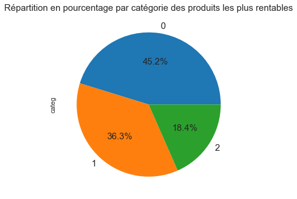

```python
cat=[0,1,2]
trp305.categ.value_counts().plot.pie(autopct=lambda x:f'{x:.1f}%',labels=cat,textprops={'fontsize': 15})
plt.title("Répartition en pourcentage par catégorie des produits les plus rentables",fontsize=15)
plt.show()
```

# Les clients

```python
trp451=trp89[['client_id', 'price']].groupby('client_id').agg({'price': ['count', 'sum']}).reset_index()
```

```python
trp451.columns=['client_id','nbventes','CA']
```

```python
trp452=trp451.sort_values(by='CA',ascending=False)
```

```python
trp452['client_id'].unique().shape[0]/2
```

```
4300.0
```

```python
(trp452['CA'].head(4300).sum()/trp452['CA'].sum())*100
```

```
80.05867042615725
```

50% des clients les plus dépensiers représentent 80% du chiffre d'affaires.

```python
trp453=trp451.sort_values(by='nbventes',ascending=False)
```

```python
(trp453['nbventes'].head(4300).sum()/trp453.nbventes.sum())*100
```

```
82.72965206997462
```

50 % des clients qui achètent le plus représentent 83 % des ventes.

```python
trp452.head(4)
```

|  | client_id | nbventes | CA |
| --- | --- | --- | --- |
| 677 | c_1609 | 25488 | 324033.350000 |
| 4388 | c_4958 | 5195 | 289760.340000 |
| 6337 | c_6714 | 9187 | 153730.059848 |
| 2724 | c_3454 | 6773 | 113703.499924 |

```python
(trp452['CA'].head(4).sum()/trp452.CA.sum())*100
```

```
7.431149517748567
```

Voici les 4 plus gros clients , ils représentent 7.4% du CA total.

# Test de Pearson avec la fréquence d'achats (moyenne du nombre d'achats par mois) et l' age

```python
tr784=trp89.groupby(['client_id','Age',"groupe d'age",'Month']).agg({'price':['count']}).reset_index()
```

```python
tr784.columns=['client_id','Age',"groupe d'age",'Month','nbachats']
```

```python
tr785=tr784.groupby(['client_id','Age',"groupe d'age"]).agg({'nbachats': 'mean'}).reset_index()
```

```python
tr785
```

|  | client_id | Age | groupe d'age | nbachats |
| --- | --- | --- | --- | --- |
| 0 | c_1 | 66 | 57-76 | 3.250000 |
| 1 | c_10 | 65 | 57-76 | 5.272727 |
| 2 | c_100 | 29 | 17-36 | 1.600000 |
| 3 | c_1000 | 55 | 37-56 | 10.416667 |
| 4 | c_1001 | 39 | 37-56 | 8.500000 |
| ... | ... | ... | ... | ... |
| 8595 | c_995 | 66 | 57-76 | 2.000000 |
| 8596 | c_996 | 51 | 37-56 | 7.916667 |
| 8597 | c_997 | 27 | 17-36 | 4.916667 |
| 8598 | c_998 | 20 | 17-36 | 5.300000 |
| 8599 | c_999 | 57 | 57-76 | 4.181818 |

```python
tr786=tr785.groupby('Age').mean().reset_index()
```

```python
tr786
```

|  | Age | nbachats |
| --- | --- | --- |
| 0 | 17 | 3.680132 |
| 1 | 18 | 3.338024 |
| 2 | 19 | 3.415466 |
| 3 | 20 | 3.643920 |
| 4 | 21 | 3.618719 |
| ... | ... | ... |
| 71 | 88 | 4.253788 |
| 72 | 89 | 4.806145 |
| 73 | 90 | 4.374053 |
| 74 | 91 | 5.050000 |
| 75 | 92 | 5.676768 |

On pose les hypothèses de départ :

- H0 : Variables indépendantes si p-value > 5%
- H1 : Variables non indépendantes si p-value < 5%

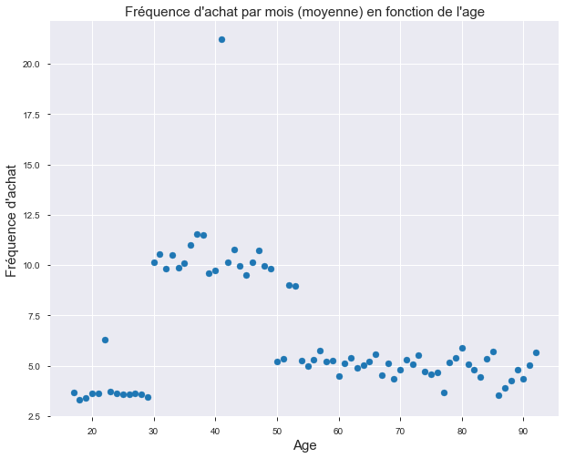

```python
plt.figure(figsize=(10,8))
plt.scatter(tr786['Age'],tr786['nbachats'])
plt.xlabel("Age",fontsize=15)
plt.ylabel("Fréquence d'achat",fontsize=15)
plt.title("Fréquence d'achat par mois (moyenne) en fonction de l'age",fontsize=15)
plt.show()
```

```python
Coeff,p=pearsonr(tr786['Age'],tr786['nbachats'])
print(f'Le coefficient de corrélation vaut {Coeff:.2f} et la p-valeur vaut {p}.')
```

```
Le coefficient de corrélation vaut -0.27 et la p-valeur vaut 0.02002756638429699.
```

# Anova sur les groupes d'age et la fréquence d'achat (moyenne du nombre d'achats par mois)

```python
tr785.sort_values(by='nbachats',ascending=False)
```

|  | client_id | Age | groupe d'age | nbachats |
| --- | --- | --- | --- | --- |
| 677 | c_1609 | 41 | 37-56 | 2124.000000 |
| 6337 | c_6714 | 53 | 37-56 | 765.583333 |
| 2724 | c_3454 | 52 | 37-56 | 564.416667 |
| 4388 | c_4958 | 22 | 17-36 | 432.916667 |
| 2513 | c_3263 | 36 | 17-36 | 33.583333 |
| ... | ... | ... | ... | ... |
| 8345 | c_8527 | 17 | 17-36 | 1.000000 |
| 1363 | c_2226 | 52 | 37-56 | 1.000000 |
| 4525 | c_5080 | 27 | 17-36 | 1.000000 |
| 3810 | c_4436 | 28 | 17-36 | 1.000000 |
| 4197 | c_4786 | 54 | 37-56 | 1.000000 |

Dans une ANOVA, on cherche à déterminer si les moyennes des groupes sont significativement différentes.

On pose donc :

- H0 : Les moyennes de chaque groupe sont égales si p-value > 5%
- H1 : Les moyennes de chaque groupe ne sont pas toutes égales si p-value < 5%

```python
C="groupe d'age" #qualitative
D="nbachats" #quantitative
```

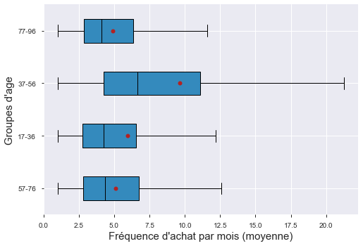

```python
modalites = tr785[C].unique()
groupes = []
for m in modalites:
    groupes.append(tr785[tr785[C]==m][D])


medianprops = {'color':"black"}
meanprops = {'marker':'o', 'markeredgecolor':'black',
            'markerfacecolor':'firebrick'}

plt.boxplot(groupes, labels=modalites, showfliers=False, medianprops=medianprops,
            vert=False, patch_artist=True, showmeans=True, meanprops=meanprops)
plt.xlabel("Fréquence d'achat par mois (moyenne)",fontsize=15)
plt.ylabel("Groupes d'age",fontsize=15)
plt.show()
```

```python
from scipy.stats import f_oneway
F, p = f_oneway(tr785[tr785[C]=='17-36'][D],
                tr785[tr785[C]=='37-56'][D],
                tr785[tr785[C]=='57-76'][D],
                tr785[tr785[C]=='77-96'][D])
print(f'la F-valeur vaut {F:.2f} et la p-valeur vaut {p}.')
```

```
la F-valeur vaut 16.70 et la p-valeur vaut 8.118023838514906e-11.
```

```python
k=eta_squared(tr785[C],tr785[D])
print(f'Le eta_squared vaut {k :.2f}.')
```

```
Le eta_squared vaut 0.01.
```

# Test de Pearson pour l'Age et la taille du panier moyen.

On pose les hypothèses de départ :

- H0 : Variables indépendantes si p-value > 5%
- H1 : Variables non indépendantes si p-value < 5%

```python
trf=trp6[['client_id','session_id','id_prod','Age',"groupe d'age"]]
```

```python
trf1=trf.groupby(['client_id','session_id','Age',"groupe d'age"]).count().reset_index()
```

```python
trf2=trf1.groupby(['client_id',"Age","groupe d'age"]).agg({'id_prod':'mean'}).reset_index()
```

```python
trf2=trf2.rename(columns={'id_prod':'tpaniermoy'})
```

```python
trf3=trf2.groupby('Age').mean().reset_index()
```

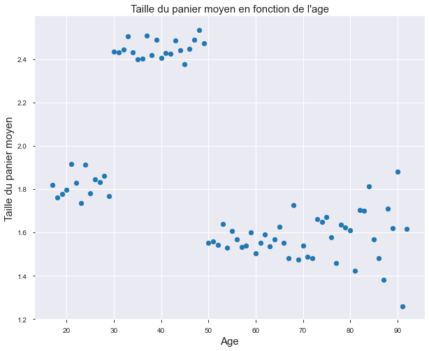

```python
plt.figure(figsize=(10,8))
plt.scatter(trf3['Age'],trf3['tpaniermoy'])
plt.xlabel("Age",fontsize=15)
plt.ylabel("Taille du panier moyen",fontsize=15)
plt.title("Taille du panier moyen en fonction de l'age",fontsize=15)
plt.show()
```

```python
Coeff,p=pearsonr(trf3['Age'],trf3['tpaniermoy'])
print(f'Le coefficient de corrélation vaut {Coeff:.2f} et la p-valeur vaut {p}.')
```

```
Le coefficient de corrélation vaut -0.56 et la p-valeur vaut 1.9581177100198017e-07.
```

# Anova entre groupes d'age et taille du panier moyen

```python
Q="groupe d'age"
L="tpaniermoy"
```

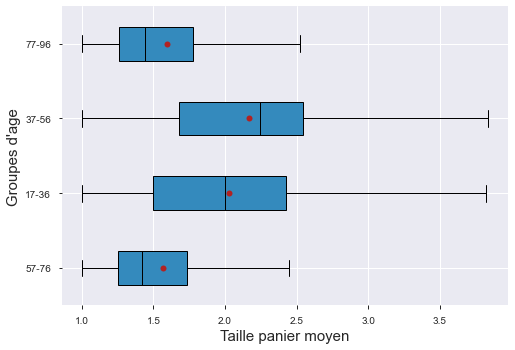

```python
modalites = trf2[Q].unique()
groupes = []
for m in modalites:
    groupes.append(trf2[trf2[Q]==m][L])


medianprops = {'color':"black"}
meanprops = {'marker':'o', 'markeredgecolor':'black',
            'markerfacecolor':'firebrick'}

plt.boxplot(groupes, labels=modalites, showfliers=False, medianprops=medianprops,
            vert=False, patch_artist=True, showmeans=True, meanprops=meanprops)
plt.xlabel("Taille panier moyen",fontsize=15)
plt.ylabel("Groupes d'age",fontsize=15)
plt.show()
```

```python
from scipy.stats import f_oneway
F, p = f_oneway(trf2[trf2[Q]=='17-36'][L],
                trf2[trf2[Q]=='37-56'][L],
                trf2[trf2[Q]=='57-76'][L],
                trf2[trf2[Q]=='77-96'][L])
print(f'la F-valeur vaut {F:.2f} et la p-valeur vaut {p}.')
```

```
la F-valeur vaut 380.40 et la p-valeur vaut 5.244500283701591e-232.
```

```python
eta_squared(trf2[Q],trf2[L])
```

```
0.11720025394598946
```